# Waterlogging microbiome analysis

Hamish McLean

2026-01-29

## 1 Setup

```r
library(buildmer)
library(car)
library(ComplexHeatmap)
library(cowplot)
library(data.table)
library(DESeq2)
library(dplyr)
library(DT)
library(emmeans)
library(ggguides)
library(ggpubr)
library(gplots)
library(gridExtra)
library(here)
library(kableExtra)
library(lmerTest)
library(lme4)
library(lmPerm)
library(partR2)
library(patchwork)
library(performance)
library(permutes)
library(ragg)
library(rstatix)
library(see)
library(stringr)
library(tidyr)
library(vegan)
library(viridis)
```

```r
here <- here::here()

FUNC_DIR <- here("functions")

source(here(FUNC_DIR, "functions.R"))
source(here(FUNC_DIR, "loadme.R"))
source(here(FUNC_DIR, "metabarcoding.R"))
source(here(FUNC_DIR, "metafuncs.R"))
source(here(FUNC_DIR, "rarefaction.R"))

# knit_print.datatable <- function(x, ...) {
#   htmltools::browsable(x)
# }
```

```r
DATA_DIR    <- normalizePath(here("..", "Data"))
FIGURES_DIR <- here("figures")
OBJECT_DIR  <- here("objects")

# Bioinformatics pipeline (defaults to DADA2)
# This should be set in the YAML header or passed as a parameter
PIPELINE    <- params$pipeline # DADA2 or USEARCH
ASV_FILTER  <- 0.001 # ASV filter for removing low abundance ASVs
READ_FILTER <- 0.05  # Read count filter for rarefaction
TAX_CONF    <- 0.80  # Confidence threshold for taxonomic rank assignment
SEED        <- 25647 # Random seed

alpha_cache <- params$alpha_cache

# Colour blind palette
cbPalette   <- c(
  "#000000", "#E69F00", "#56B4E9", "#009E73",
  "#F0E442", "#0072B2", "#D55E00", "#CC79A7"
)

# Model designs
# Timepoint model for E1
T_DESIGN   <- ~ block + timepoint * treatment + Error(plot)
T_DESIGN_M <- ~ timepoint * treatment + (1 | plot)

# Experiment model without timepoint 2
E_DESIGN   <- ~ experiment:block + experiment * treatment
E_DESIGN_M <- ~ experiment * treatment + (1 | experiment:block)
```

## 2 Load data

Load data from R objects.

```r
FUN  <- readRDS(here(OBJECT_DIR, "FUN.rds"))
BAC  <- readRDS(here(OBJECT_DIR, "BAC.rds"))

EXP  <- readRDS(here(OBJECT_DIR, "EXP.rds"))
TIME <- readRDS(here(OBJECT_DIR, "TIME.rds"))
```

## 3 Community size

### 3.1 Copy number plots

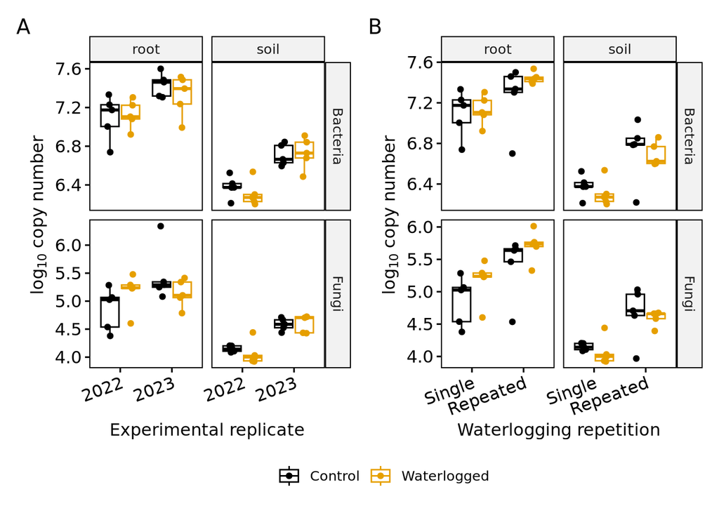

```r
copyNumberPlot <- function(data, x, xlab = NULL) {
  ggboxplot(
    data,
    x = x,
    y = "log10_copy_number",
    color = "treat_label",
    # fill = "weeks",
    add = c("jitter"),
    # jitter.color = "weeks",
    # jitter.alpha = 0.1,
    # jitter.width = 0.1,
    facet.by = c("type", "source"),
    palette = cbPalette,
    scales = "free",
    legend = "bottom"
  ) + labs(
    x = ifelse(!is.null(xlab), xlab, x),
    y = bquote(log[10] ~ "copy number"),
    color = NULL
  ) +
  rotate_x_text(20)
  #+ scale_color_viridis(discrete = TRUE, option = "D")
}

copy_number_combined <- rbind(
  FUN$colData %>% mutate(type = "Fungi"),
  BAC$colData %>% mutate(type = "Bacteria")
)

# Experiment
exp_cn_plot <- copyNumberPlot(filter(copy_number_combined, timepoint == 1), "exp_year", "Experimental replicate")
ggsave(filename = "CN_EXP.png", path = FIGURES_DIR)

# Timepoint
time_cn_plot <- copyNumberPlot(filter(copy_number_combined, experiment == 1), "treat_rep", "Waterlogging repetition")
ggsave(filename = "CN_TIME.png", path = FIGURES_DIR)

# Combined
collect_legends(exp_cn_plot | time_cn_plot, position = "bottom") + plot_annotation(tag_levels = "A")
```

```r
ggsave(
  filename = "CN_combined.png", path = FIGURES_DIR,
  width = 22, height = 15, units = "cm"
)
```

### 3.2 Copy number models

#### 3.2.1 Linear mixed effects models

```r
exp_cn  <- apply_to_subsets(EXP, copyNumberModelLMM, E_DESIGN_M) |> combineTables()
time_cn <- apply_to_subsets(TIME, copyNumberModelLMM, T_DESIGN_M) |> combineTables()

# exp_cn  [P <= 0.05 & factor != "(Intercept)"] |> printTable("Experiment")
# time_cn [P <= 0.05 & factor != "(Intercept)"] |> printTable("Timepoint")

# Full tables
exp_cn  |> printTable("Experiment")
time_cn |> printTable("Timepoint")


# lmer(update(E_DESIGN_M, copy_number ~ .), EXP$FUN$soil$colData) |> residuals() |> qqnorm()
```

#### 3.2.2 Linear models

```r
# apply_to_subsets(EXP, copyNumberModelLM, E_DESIGN) |> combineTables()

# apply_to_subsets(TIME, copyNumberModelLM, T_DESIGN) |> combineTables()


# a <- aov(update(T_DESIGN, copy_number ~ .), TIME$FUN$soil$colData)
# ggqqplot(residuals(a))
# ggsave(filename = "test_plot.png", path = FIGURES_DIR)

# summary(a)

genericAnova <- function(data, kingdom, source, design) {
  anova    <- aov(design, data$colData)
  anova_df <- summary(anova)[[1]]
  total_ss <- sum(anova_df[["Sum Sq"]])
  data.table(
    kingdom = kingdom,
    source  = source,
    factor  = rownames(anova_df) |> trimws(),
    df      = anova_df[["Df"]],
    SS      = anova_df[["Sum Sq"]],
    MS      = anova_df[["Mean Sq"]],
    F       = anova_df[["F value"]],
    P       = anova_df[["Pr(>F)"]],
    stars   = p_stars(anova_df[["Pr(>F)"]]),
    ges     = anova_df[["Sum Sq"]] / total_ss
  )
}

exp_cn_lm <- apply_to_subsets(EXP, genericAnova, update(E_DESIGN, log10(copy_number) ~ .)) |> combineTables()

exp_cn_lm |> printTable("Experiment")
```

| kingdom | source | factor | df | SS | MS | F | P | stars | ges |
| --- | --- | --- | --- | --- | --- | --- | --- | --- | --- |
| FUN | root | experiment | 1 | 0.4146589197629199 | 0.4146589197629199 | 3.030803742902988 | 0.1198765666535427 |  | 0.1302722572718134 |
| FUN | root | treatment | 1 | 0.0001596084720827073 | 0.0001596084720827073 | 0.001166602071080189 | 0.9735899358835267 |  | 5.014375658386315e-05 |
| FUN | root | experiment:block | 8 | 1.180942964405563 | 0.1476178705506954 | 1.078960980364818 | 0.4585181748583662 |  | 0.3710136170960449 |
| FUN | root | experiment:treatment | 1 | 0.4927376583700454 | 0.4927376583700454 | 3.601492860954322 | 0.09429263623965771 | . | 0.1548020407601359 |
| FUN | root | Residuals | 8 | 1.094518695204588 | 0.1368148369005735 |  |  |  | 0.3438619411154218 |
| FUN | soil | experiment | 1 | 1.182243057655267 | 1.182243057655267 | 54.0499433911808 | 7.979557720027034e-05 | *** | 0.7670482529001802 |
| FUN | soil | treatment | 1 | 0.005401244785223732 | 0.005401244785223732 | 0.2469348185154493 | 0.6326082308986615 |  | 0.003504368538402654 |
| FUN | soil | experiment:block | 8 | 0.1664926301026454 | 0.02081157876283067 | 0.9514664913685629 | 0.5271850445292179 |  | 0.108021679817915 |
| FUN | soil | experiment:treatment | 1 | 0.01216681774561594 | 0.01216681774561594 | 0.5562441717404538 | 0.4771174927298135 |  | 0.0078939235334896 |
| FUN | soil | Residuals | 8 | 0.174985279684592 | 0.021873159960574 |  |  |  | 0.1135317752100125 |

[output cut: 10 more lines]

```r
# apply_to_subsets(TIME, genericAnova, update(T_DESIGN, log10_copy_number ~ .)) |> combineTables()


timepointAnova <- function(data, kingdom, source, design) {
  anova     <- aov(update(design, log10(copy_number)  ~ .), data$colData)
  plot_df   <- summary(anova)[["Error: plot"]][[1]]
  # plot_ss   <- sum(plot_df[["Sum Sq"]])
  # plot_df$var <- plot_df[["Sum Sq"]] / plot_ss * 100
  within_df <- summary(anova)[["Error: Within"]][[1]]
  # within_ss <- sum(within_df[["Sum Sq"]])
  # within_df$var <- within_df[["Sum Sq"]] / within_ss * 100
  anova_df  <- bind_rows(plot_df, within_df)

  grand_mean <- mean(data$colData$log10_copy_number, na.rm = TRUE)
  total_ss   <- sum((data$colData$log10_copy_number - grand_mean)^2, na.rm = TRUE)
  data.table(
    kingdom = kingdom,
    source  = source,
    factor  = rownames(anova_df) |> trimws(),
    df      = anova_df[["Df"]],
    SS      = anova_df[["Sum Sq"]],
    MS      = anova_df[["Mean Sq"]],
    F       = anova_df[["F value"]],
    P       = anova_df[["Pr(>F)"]],
    stars   = p_stars(anova_df[["Pr(>F)"]]),
    ges     = anova_df[["Sum Sq"]] / total_ss
  )
}

# timepointAnova(TIME$FUN$soil, "Fungi", "soil", T_DESIGN)

time_cn_lm <- apply_to_subsets(TIME, timepointAnova, T_DESIGN) |> combineTables()

time_cn_lm |> printTable("Timepoint")
```

| kingdom | source | factor | df | SS | MS | F | P | stars | ges |
| --- | --- | --- | --- | --- | --- | --- | --- | --- | --- |
| FUN | root | block | 4 | 0.7480151509766565 | 0.1870037877441641 | 1.012704540072159 | 0.4952659328202555 |  | 0.1787397124053706 |
| FUN | root | treatment | 1 | 0.4712937469769345 | 0.4712937469769345 | 2.55225481274272 | 0.1853773520373274 |  | 0.1126165809383929 |
| FUN | root | Residuals | 4 | 0.7386311815323328 | 0.1846577953830832 |  |  |  | 0.176497394188274 |
| FUN | root | timepoint | 1 | 1.470249610128308 | 1.470249610128308 | 15.54119957533448 | 0.004282448560333775 | ** | 0.351319077073939 |
| FUN | root | timepoint:treatment | 1 | 7.900306054417443e-06 | 7.900306054417443e-06 | 8.35097878973148e-05 | 0.9929325139756631 |  | 1.887793890587986e-06 |
| FUN | root | Residuals | 8 | 0.7568268346346952 | 0.0946033543293369 |  |  |  | 0.1808452817922855 |
| FUN | soil | block | 4 | 0.1501734684499647 | 0.03754336711249116 | 0.738946194015607 | 0.611745573829947 |  | 0.06411695582526401 |
| FUN | soil | treatment | 1 | 0.02707347956184002 | 0.02707347956184002 | 0.5328729471983029 | 0.5058534940514797 |  | 0.01155909303434014 |
| FUN | soil | Residuals | 4 | 0.2032265267297566 | 0.05080663168243914 |  |  |  | 0.08676809806250901 |
| FUN | soil | timepoint | 1 | 1.353431291034513 | 1.353431291034513 | 17.80498326806702 | 0.002917432850237904 | ** | 0.577851035841946 |

[output cut: 14 more lines]

```r
# t <- log10_copy_number ~ block + timepoint * treatment + Error(plot)

# lm(t, TIME$FUN$soil$colData)

# anova_test(
#   TIME$FUN$soil$colData,
#   formula = log10_copy_number ~ block + timepoint * treatment,# + Error(plot),
#   # dv = log10_copy_number,
#   # wid = plot,
#   # # between = c(block, treatment),
#   # within = timepoint,
#   type = 3,
#   effect.size = "res"
# )


# anova_test(
#   TIME$FUN$soil$colData,
#   log10_copy_number ~ block + timepoint * treatment + Error(plot),
#   type = 3,
#   effect.size = "res"
# )


# emmeans
emmMain <- function(model, k, s, specs, section = NULL) {
  # dat <- data[[k]][[s]]$colData
  # model <- aov(update(design, log10(copy_number) ~ .), data$colData)
  emm <- emmeans(model, specs, type = "response") |> suppressMessages()
  # return(emm)
  res <- if(is.null(section)) emm else emm[[section]] |> as.data.frame()
  mutate(res, kingdom = k, source = s)
}

e_anova <- apply_to_subsets(
  EXP, function(data, k, s, design) aov(design, data$colData),
  update(E_DESIGN, log10(copy_number) ~ .)
)

# t_anova <- apply_to_subsets(
#   TIME, function(data, k, s, design) aov(design, data$colData),
#   update(T_DESIGN, log10(copy_number) ~ .)
# )

# emmMain(e_anova$FUN$root, "FUN", "root", pairwise ~ experiment, "contrasts", EXP)
# emmMain(t, "k", "s", pairwise ~ timepoint, "contrasts")
# emmMain(t_anova$FUN$root, "k", "s", pairwise ~ timepoint, "contrasts", TIME)
# emmMain(t_anova$FUN$root, "FUN", "root", ~ timepoint, data = TIME)


# Experiment
# All experiment contrasts
apply_to_subsets(e_anova, emmMain, pairwise ~ experiment, "emmeans") |>
  combineTables() |> printTable("Experiment")
```

| experiment | emmean | SE | df | lower.CL | upper.CL | kingdom | source |
| --- | --- | --- | --- | --- | --- | --- | --- |
| 1 | 5.013016834041104 | 0.116967874606908 | 8 | 4.743288431511532 | 5.282745236570676 | FUN | root |
| 2 | 5.300995624844496 | 0.1169678746069081 | 8 | 5.031267222314924 | 5.570724027374069 | FUN | root |
| 1 | 4.107074964110424 | 0.046768750208418 | 8 | 3.999226032731482 | 4.214923895489367 | FUN | soil |
| 2 | 4.593334783066354 | 0.04676875020841797 | 8 | 4.485485851687412 | 4.701183714445297 | FUN | soil |
| 1 | 7.111486166593954 | 0.06531575365447224 | 8 | 6.960867768572764 | 7.262104564615144 | BAC | root |
| 2 | 7.379788963993716 | 0.06531575365447229 | 8 | 7.229170565972526 | 7.530407362014905 | BAC | root |
| 1 | 6.343536696446731 | 0.04219307148379623 | 8 | 6.246239299128132 | 6.440834093765329 | BAC | soil |
| 2 | 6.718648191996118 | 0.04219307148379616 | 8 | 6.621350794677519 | 6.815945589314716 | BAC | soil |

```r
apply_to_subsets(e_anova, emmMain, pairwise ~ experiment, "contrasts") |>
  combineTables() |> printTable("Experiment")
```

| contrast | estimate | SE | df | t.ratio | p.value | kingdom | source |
| --- | --- | --- | --- | --- | --- | --- | --- |
| experiment1 - experiment2 | -0.2879787908033924 | 0.1654175546310448 | 8 | -1.74092037236141 | 0.1198765666535426 | FUN | root |
| experiment1 - experiment2 | -0.4862598189559295 | 0.06614100083998423 | 8 | -7.351866660323815 | 7.979557720027006e-05 | FUN | soil |
| experiment1 - experiment2 | -0.2683027973997614 | 0.09237042465477467 | 8 | -2.904639644155763 | 0.01975070899171431 | BAC | root |
| experiment1 - experiment2 | -0.3751114955493872 | 0.05967001393056209 | 8 | -6.286432176568685 | 0.0002362179427409642 | BAC | soil |

```r
# Timepoint
# All timepoint contasts
# apply_to_subsets(TIME, emmMain, T_DESIGN, pairwise ~ timepoint, "emmeans") |> combineTables()
# apply_to_subsets(t_anova, emmMain, pairwise ~ timepoint, "contrasts", TIME) |> combineTables()

# apply_to_subsets(t_anova, emmMain, ~ timepoint, data = TIME) |> combineTables()

# emmMain <- function(data, k, s, design, specs, section = NULL) {
#   model <- aov(design, data$colData)
#   emm <- emmeans(model, specs, type = "response") |> suppressMessages()
#   return(emm)
#   # return(emm)
#   res <- if(is.null(section)) emm else emm[[section]] |> as.data.frame()
#   mutate(res, kingdom = k, source = s)
# }


t_design <- update(T_DESIGN, log10(copy_number) ~ .)

# emmMain(TIME$FUN$soil, "FUN", "soil", t_design, pairwise ~ timepoint)

emmeans(aov(t_design, TIME$FUN$soil$colData), pairwise ~ timepoint, type = "response")
```

```
## $emmeans
##  timepoint response   SE   df lower.CL upper.CL
##  1            12796 2350 11.8     8574    19097
##  2            42398 7770 11.8    28409    63277
##
## Results are averaged over the levels of: block, treatment
## Warning: EMMs are biased unless design is perfectly balanced
## Confidence level used: 0.95
## Intervals are back-transformed from the log10 scale
##
## $contrasts
##  contrast                ratio     SE df null t.ratio p.value
##  timepoint1 / timepoint2 0.302 0.0857  8    1  -4.220  0.0029
##
## Results are averaged over the levels of: block, treatment
## Tests are performed on the log10 scale
```

```r
emmeans(aov(t_design, TIME$BAC$root$colData), pairwise ~ timepoint, type = "response")
```

```
## $emmeans
##  timepoint response      SE   df lower.CL upper.CL
##  1         12926655 2050000 5.18  8639355 19341539
##  2         22499456 3560000 5.18 15037206 33664866
##
## Results are averaged over the levels of: block, treatment
## Warning: EMMs are biased unless design is perfectly balanced
## Confidence level used: 0.95
## Intervals are back-transformed from the log10 scale
##
## $contrasts
##  contrast                ratio     SE df null t.ratio p.value
##  timepoint1 / timepoint2 0.575 0.0644  8    1  -4.942  0.0011
##
## Results are averaged over the levels of: block, treatment
## Tests are performed on the log10 scale
```

```r
emmeans(aov(t_design, TIME$FUN$soil$colData), pairwise ~ timepoint, type = "response")
```

```
## $emmeans
##  timepoint response   SE   df lower.CL upper.CL
##  1            12796 2350 11.8     8574    19097
##  2            42398 7770 11.8    28409    63277
##
## Results are averaged over the levels of: block, treatment
## Warning: EMMs are biased unless design is perfectly balanced
## Confidence level used: 0.95
## Intervals are back-transformed from the log10 scale
##
## $contrasts
##  contrast                ratio     SE df null t.ratio p.value
##  timepoint1 / timepoint2 0.302 0.0857  8    1  -4.220  0.0029
##
## Results are averaged over the levels of: block, treatment
## Tests are performed on the log10 scale
```

```r
emmeans(aov(t_design, TIME$BAC$root$colData), pairwise ~ timepoint, type = "response")
```

```
## $emmeans
##  timepoint response      SE   df lower.CL upper.CL
##  1         12926655 2050000 5.18  8639355 19341539
##  2         22499456 3560000 5.18 15037206 33664866
##
## Results are averaged over the levels of: block, treatment
## Warning: EMMs are biased unless design is perfectly balanced
## Confidence level used: 0.95
## Intervals are back-transformed from the log10 scale
##
## $contrasts
##  contrast                ratio     SE df null t.ratio p.value
##  timepoint1 / timepoint2 0.575 0.0644  8    1  -4.942  0.0011
##
## Results are averaged over the levels of: block, treatment
## Tests are performed on the log10 scale
```

```r
# e <- aov(update(E_DESIGN, log10(copy_number) ~ .), EXP$FUN$soil$colData)

# emmeans(e, ~ experiment, type = "response")
# emmeans(e, pairwise ~ experiment, type = "response")
# emmeans(e, pairwise ~ treatment|experiment, type = "response")
# emmeans(e, trt.vs.ctrl ~ treatment|experiment, type = "response")
# emmeans(e, specs = "experiment", by = "treatment", type = "response")


# t <- aov(update(T_DESIGN, log10(copy_number) ~ .), TIME$FUN$soil$colData)

# emmeans(t, ~ timepoint, type = "response")
# emmeans(t, pairwise ~ timepoint, type = "response")
# emmeans(t, pairwise ~ treatment|timepoint, type = "response")
# emmeans(t, trt.vs.ctrl ~ treatment|timepoint, type = "response")
```

## 4 Alpha diversity

### 4.1 Calculate alpha diversity

Add alpha diversity idices to data objects.

```r
EXP  <- apply_to_subsets(EXP, calculateAlpha)
TIME <- apply_to_subsets(TIME, calculateAlpha)
```

### 4.2 Permutation anova of alpha diversity index ranks

`perm.lmer` runs a permutation test for mixed-effects models. This model takes a long time to run, so results are cached.

```r
# These models are very slow, only run to update the cached results
if (!alpha_cache) {
  # Define metrics
  metrics <- c("S.chao1", "shannon", "simpson")

  exp_alpha  <- apply_to_subsets(EXP, alphaModel, metrics, E_DESIGN_M) |> combineTables()
  time_alpha <- apply_to_subsets(TIME, alphaModel, metrics, T_DESIGN_M) |> combineTables()

  saveRDS(exp_alpha,  here(OBJECT_DIR, "exp_alpha.rds"))
  saveRDS(time_alpha, here(OBJECT_DIR, "time_alpha.rds"))
} else {
  exp_alpha  <- readRDS(here(OBJECT_DIR, "exp_alpha.rds"))
  time_alpha <- readRDS(here(OBJECT_DIR, "time_alpha.rds"))
}

# exp_alpha [p <= 0.05 & factor != "(Intercept)"] |> printTable()
# time_alpha[p <= 0.05 & factor != "(Intercept)"] |> printTable()

# Full tables
exp_alpha  |> printTable()
time_alpha |> printTable()
```

#### 4.2.1 Alpha post-hoc (LMM)

```r
# EXP FUN root Simpson: NS, mean(simpson) slightly higher in treated for both
alphaPostHoc(EXP$FUN$root$alphaData, "simpson", formula(~ treatment + (1 | block)), "experiment")

# EXP FUN soil Chao1: NS, mean(Chao1) slighly higher in E1 trt, lower in E2 trt
alphaPostHoc(EXP$FUN$soil$alphaData, "S.chao1", formula(~ treatment + (1 | block)), "experiment")

# EXP BAC soil Simpson: NS, mean(Simpson) slightly lower in treated for both
alphaPostHoc(EXP$BAC$soil$alphaData, "simpson", formula(~ treatment + (1 | block)), "experiment")



# TIME FUN soil Simpson: T1 ns, T2 *, higher in treated
alphaPostHoc(TIME$FUN$soil$alphaData, "simpson", formula(~ treatment + (1 | block)), "timepoint")

# TIME FUN soil Shannon: both ns, both lower in treated
alphaPostHoc(TIME$FUN$soil$alphaData, "shannon", formula(~ treatment + (1 | block)), "timepoint")

# TIME BAC root Chao1: both ns,
alphaPostHoc(TIME$BAC$root$alphaData, "S.chao1", formula(~ treatment + (1 | block)), "timepoint")

# TIME BAC soil Simpson: T1 ns, T2 *, lower in treated
alphaPostHoc(TIME$BAC$soil$alphaData, "simpson", formula(~ treatment + (1 | block)), "timepoint")
```

### 4.3 Alpha diversity linear models

```r
metrics <- c("S.chao1", "shannon", "simpson")

# aovp(update(E_DESIGN, rank(shannon) ~ .), EXP$FUN$soil$alphaData) |> summary()

# alphaLM(EXP$FUN$soil, "FUN", "soil", metrics, E_DESIGN)

exp_alpha <- apply_to_subsets(EXP, alphaLM, metrics, E_DESIGN)
```

[output not shown]

```r
exp_alpha |> combineTables() |> printTable("Experiment")
```

| kingdom | source | metric | factor | df | SS | MS | Iter | p | stars | var |
| --- | --- | --- | --- | --- | --- | --- | --- | --- | --- | --- |
| FUN | root | S.chao1 | experiment | 1 | 1.800000000000011 | 1.800000000000011 | 5000 | 0.0088 | ** | 0.270676691729325 |
| FUN | root | S.chao1 | treatment | 1 | 0.1999999999999971 | 0.1999999999999971 | 51 | 1 |  | 0.03007518796992437 |
| FUN | root | S.chao1 | experiment:treatment | 1 | 0.2000000000000002 | 0.2000000000000002 | 51 | 0.8627450980392157 |  | 0.03007518796992485 |
| FUN | root | S.chao1 | experiment1:block | 8 | 612.2 | 76.525 | 5000 | 0 | *** | 92.06015037593986 |
| FUN | root | S.chao1 | Residuals | 8 | 50.60000000000001 | 6.325000000000001 |  |  |  | 7.609022556390979 |
| FUN | root | shannon | experiment | 1 | 145.8 | 145.8 | 5000 | 0 | *** | 21.92481203007518 |
| FUN | root | shannon | treatment | 1 | 1.282988954315876e-31 | 1.282988954315876e-31 | 51 | 1 |  | 1.929306698219363e-32 |
| FUN | root | shannon | experiment:treatment | 1 | 0.7999999999999986 | 0.7999999999999986 | 56 | 0.6428571428571429 |  | 0.120300751879699 |
| FUN | root | shannon | experiment1:block | 8 | 368.2 | 46.025 | 5000 | 0.0028 | ** | 55.36842105263158 |
| FUN | root | shannon | Residuals | 8 | 150.2 | 18.775 |  |  |  | 22.58646616541353 |

[output cut: 50 more lines]

```r
# alphaLM(TIME$FUN$soil, "FUN", "soil", metrics, T_DESIGN)

singleAlphaLM <- function(data, kingdom, source, metric, design) {
  formula <- update(design, as.formula(paste0("rank(", metric, ") ~ .")))
  anova <- aovp(formula, data, seqs = TRUE)
  anova_df <- bind_rows(
    summary(anova)[["Error: plot"]][[1]] |> as.data.frame(),
    summary(anova)[["Error: Within"]][[1]] |> as.data.frame()
  )
  metric_rank <- rank(data[[metric]])
  anova_df$met <- metric
  anova_df$factor <- rownames(anova_df) |> trimws()
  anova_df$total_ss <- sum((metric_rank - mean(metric_rank))^2)
  data.table(
    kingdom = kingdom,
    source  = source,
    metric  = anova_df$met,
    factor  = anova_df$factor,
    df      = anova_df[["Df"]],
    SS      = anova_df[["R Sum Sq"]],
    MS      = anova_df[["R Mean Sq"]],
    Iter    = anova_df[["Iter"]],
    p       = anova_df[["Pr(Exact)"]],
    stars   = p_stars(anova_df[["Pr(Exact)"]]),
    var     = anova_df[["R Sum Sq"]] / anova_df$total_ss * 100
  )
}

# singleAlphaLM(TIME$FUN$soil$alphaData, "FUN", "soil", "S.chao1", T_DESIGN)

time_alpha <- list(
  FUN = list(
    root = bind_rows(
      singleAlphaLM(TIME$FUN$root$alphaData, "FUN", "root", "S.chao1", T_DESIGN),
      singleAlphaLM(TIME$FUN$root$alphaData, "FUN", "root", "shannon", T_DESIGN),
      singleAlphaLM(TIME$FUN$root$alphaData, "FUN", "root", "simpson", T_DESIGN)
    ),
    soil = bind_rows(
      singleAlphaLM(TIME$FUN$soil$alphaData, "FUN", "soil", "S.chao1", T_DESIGN),
      singleAlphaLM(TIME$FUN$soil$alphaData, "FUN", "soil", "shannon", T_DESIGN),
      singleAlphaLM(TIME$FUN$soil$alphaData, "FUN", "soil", "simpson", T_DESIGN)
    )
  ),
  BAC = list(
    root = bind_rows(
      singleAlphaLM(TIME$BAC$root$alphaData, "BAC", "root", "S.chao1", T_DESIGN),
      singleAlphaLM(TIME$BAC$root$alphaData, "BAC", "root", "shannon", T_DESIGN),
      singleAlphaLM(TIME$BAC$root$alphaData, "BAC", "root", "simpson", T_DESIGN)
    ),
    soil = bind_rows(
      singleAlphaLM(TIME$BAC$soil$alphaData, "BAC", "soil", "S.chao1", T_DESIGN),
      singleAlphaLM(TIME$BAC$soil$alphaData, "BAC", "soil", "shannon", T_DESIGN),
      singleAlphaLM(TIME$BAC$soil$alphaData, "BAC", "soil", "simpson", T_DESIGN)
    )
  )
)
```

[output not shown]

```r
time_alpha |> combineTables() |> printTable("Timepoint")
```

| kingdom | source | metric | factor | df | SS | MS | p | stars | var |
| --- | --- | --- | --- | --- | --- | --- | --- | --- | --- |
| FUN | root | S.chao1 | block | 4 | 108.5 | 27.125 | 0.05060074955908289 | . | 16.31578947368421 |
| FUN | root | S.chao1 | treatment | 1 | 3.200000000000009 | 3.200000000000009 | 0.519309413580247 |  | 0.4812030075187983 |
| FUN | root | S.chao1 | Residuals | 4 | 59.29999999999999 | 14.825 |  |  | 8.917293233082706 |
| FUN | root | S.chao1 | timepoint | 1 | 180 | 180 | 2.755731922398589e-07 | *** | 27.06766917293233 |
| FUN | root | S.chao1 | timepoint:treatment | 1 | 5.000000000000001 | 5.000000000000001 | 0.6466517857142857 |  | 0.7518796992481205 |
| FUN | root | S.chao1 | Residuals | 8 | 308.9999999999999 | 38.62499999999999 |  |  | 46.46616541353382 |
| FUN | root | shannon | block | 4 | 137.5 | 34.375 | 0.002854938271604938 | ** | 20.67669172932331 |
| FUN | root | shannon | treatment | 1 | 7.19999999999999 | 7.19999999999999 | 0.3680913800705468 |  | 1.082706766917292 |
| FUN | root | shannon | Residuals | 4 | 40.29999999999997 | 10.07499999999999 |  |  | 6.060150375939845 |
| FUN | root | shannon | timepoint | 1 | 168.2 | 168.2 | 2.755731922398589e-07 | *** | 25.29323308270676 |

[output cut: 62 more lines]

```r
# Summary tables

summariseAlpha <- function(data) {
  combined_data <- combineTables(data)
  combined_data$factor <- factor(combined_data$factor, levels = unique(combined_data$factor))
  dt <- dcast(
    combined_data,
    kingdom + factor + df ~ source + metric,
    value.var = c("var", "stars")
  )
  id_cols <- c("kingdom", "factor", "df")
  all_cols <- setdiff(names(dt), id_cols)
  base_cols <- unique(sub("^(var|stars)_", "", all_cols))
  final_cols <- c(
    id_cols,
    as.vector(sapply(base_cols, function(x) c(paste0("var_", x), paste0("stars_", x))))
  )
  setcolorder(dt, final_cols)
  dt
}

summariseAlpha(exp_alpha)  |> printTable("Experiment")
```

| kingdom | factor | df | var_root_S.chao1 | stars_root_S.chao1 | var_root_shannon | stars_root_shannon | var_root_simpson | stars_root_simpson | var_soil_S.chao1 | stars_soil_S.chao1 | var_soil_shannon | stars_soil_shannon | var_soil_simpson | stars_soil_simpson |
| --- | --- | --- | --- | --- | --- | --- | --- | --- | --- | --- | --- | --- | --- | --- |
| BAC | experiment | 1 | 66.43609022556392 | *** | 75.18796992481207 | *** | 75.18796992481204 | *** | 8.691729323308271 | ** | 7.699248120300759 | ** | 0.7518796992481213 |  |
| BAC | treatment | 1 | 1.924812030075188 | ** | 0.2706766917293232 | ** | 0.4812030075187977 | ** | 2.436090225563908 | ** | 0.75187969924812 | ** | 0.1203007518796983 | ** |
| BAC | experiment:treatment | 1 | 0.4812030075187972 |  | 0.4812030075187973 | ** | 0.7518796992481195 |  | 0.75187969924812 |  | 0.4812030075187965 |  | 1.082706766917293 | ** |
| BAC | experiment1:block | 8 | 11.7593984962406 | ** | 12.63157894736842 | ** | 13.08270676691729 | ** | 31.1578947368421 | * | 55.30827067669172 | ** | 83.00751879699246 | *** |
| BAC | Residuals | 8 | 19.3984962406015 |  | 11.42857142857143 |  | 10.49624060150376 |  | 56.9624060150376 |  | 35.7593984962406 |  | 15.03759398496241 |  |
| FUN | experiment | 1 | 0.270676691729325 | ** | 21.92481203007518 | *** | 32.75187969924813 | *** | 23.57894736842105 | *** | 75.18796992481204 | *** | 75.18796992481204 | *** |
| FUN | treatment | 1 | 0.03007518796992437 |  | 1.929306698219363e-32 |  | 0.1203007518796991 |  | 1.473684210526316 | ** | 2.436090225563907 |  | 3.639097744360898 | *** |
| FUN | experiment:treatment | 1 | 0.03007518796992485 |  | 0.120300751879699 |  | 4.330827067669174 | ** | 3.007518796992482 |  | 0.4812030075187985 |  | 0.481203007518798 |  |
| FUN | experiment1:block | 8 | 92.06015037593986 | *** | 55.36842105263158 | ** | 34.01503759398497 | ** | 46.79699248120303 | *** | 13.23308270676691 | ** | 13.8345864661654 | ** |
| FUN | Residuals | 8 | 7.609022556390979 |  | 22.58646616541353 |  | 28.78195488721805 |  | 25.14285714285714 |  | 8.661654135338345 |  | 6.857142857142855 |  |

```r
summariseAlpha(time_alpha) |> printTable("Timepoint")
```

| kingdom | factor | df | var_root_S.chao1 | stars_root_S.chao1 | var_root_shannon | stars_root_shannon | var_root_simpson | stars_root_simpson | var_soil_S.chao1 | stars_soil_S.chao1 | var_soil_shannon | stars_soil_shannon | var_soil_simpson | stars_soil_simpson |
| --- | --- | --- | --- | --- | --- | --- | --- | --- | --- | --- | --- | --- | --- | --- |
| BAC | block | 4 | 3.533834586466158 |  | 7.293233082706764 | * | 5.86466165413533 |  | 20.22556390977444 | * | 13.60902255639097 |  | 9.999999999999996 |  |
| BAC | treatment | 1 | 0.03007518796992489 |  | 0.2706766917293223 |  | 0.03007518796992473 |  | 3.639097744360903 |  | 0.0300751879699252 |  | 17.32330827067668 | ** |
| BAC | Residuals | 4 | 17.0375939849624 |  | 1.308270676691729 |  | 4.932330827067666 |  | 13.2781954887218 |  | 21.24812030075188 |  | 15.08270676691729 |  |
| BAC | Residuals | 8 | 13.41353383458646 |  | 15.45864661654136 |  | 13.86466165413534 |  | 61.35338345864664 |  | 54.94736842105262 |  | 41.08270676691726 |  |
| BAC | timepoint | 1 | 60.90225563909776 | *** | 75.18796992481201 | *** | 75.18796992481201 | *** | 0.03007518796992526 |  | 8.691729323308278 | . | 9.744360902255634 | ** |
| BAC | timepoint:treatment | 1 | 5.082706766917287 | * | 0.481203007518797 |  | 0.1203007518796989 |  | 1.473684210526318 |  | 1.473684210526319 |  | 6.766917293233085 |  |
| FUN | block | 4 | 16.31578947368421 | . | 20.67669172932331 | ** | 28.49624060150376 | *** | 28.57142857142855 | . | 8.872180451127825 |  | 6.917293233082717 |  |
| FUN | treatment | 1 | 0.4812030075187983 |  | 1.082706766917292 |  | 2.131938673224378e-31 |  | 5.894736842105258 |  | 1.924812030075187 |  | 3.007518796992486 |  |
| FUN | Residuals | 4 | 8.917293233082706 |  | 6.060150375939845 |  | 5.939849624060153 |  | 16.9624060150376 |  | 21.08270676691727 |  | 15.33834586466165 |  |
| FUN | Residuals | 8 | 46.46616541353382 |  | 46.76691729323309 |  | 54.34586466165415 |  | 43.00751879699249 |  | 24.66165413533832 |  | 11.42857142857143 |  |

[output cut: 2 more lines]

```r
# combineTables(exp_alpha)$factor |> as.ordered()


# Post hoc analysis

# Bacteria soil Simpson
# dat <- EXP$BAC$soil$alphaData
# dat$simpson_rank <- rank(dat$simpson)
# ## E1
# dat[experiment == 1]$simpson_rank |> mean()
# ##E2
# dat[experiment == 2]$simpson_rank |> mean()

# emmeans(
#   aovp(update(E_DESIGN, rank(simpson) ~ .), dat, seqs = TRUE)
# )

# pairwise.wilcox.test(
#   x = dat$simpson_rank, # Your response variable
#   g = dat$experiment,       # Your grouping factor
#   p.adjust.method = "bonferroni"
# )

# anovaResults <- function(data, k, s, design) {
#   anova <- aovp(update(design, measure ~ .))
#   anova_df <- if (length(anova) > 3) { # length = 3 for repeat measures anova
#     summary(anova)[[1]] # anova |> data.frame()
#   } else {
#     bind_rows(
#       summary(anova)[["Error: plot"]][[1]],
#       summary(anova)[["Error: Within"]][[1]]
#     )
#   }
#   # total_ss <- sum(anova_df["Sum Sq"])
#   total_ss <- sum((pc_dat - mean(pc_dat))^2)
#   data.table(
#     kingdom = kingdom,
#     source  = source,
#     pc      = pc_name,
#     factor  = rownames(anova_df) |> trimws(),
#     df      = anova_df[["Df"]],
#     SS      = anova_df[["Sum Sq"]],
#     MS      = anova_df[["Mean Sq"]],
#     F       = anova_df[["F value"]],
#     P       = anova_df[["Pr(>F)"]],
#     var     = anova_df[["Sum Sq"]] / total_ss * 100
#   )
# }
```

#### 4.3.1 Alpha diversity post-hoc (linear models)

```r
# Compare means between experiments

alphaPostHoc <- function(data, kingdom, source, metrics, factor, lvl) {
  dt  <- data$alphaData
  for (met in metrics) dt[, (paste0(met, "_rank")) := rank(get(met))]
  ranks <- sapply(metrics, function(met) paste0(met, "_rank"))
  res <- data.table(
    Kingdom = kingdom,
    Source  = source,
    Metric  = metrics
  )
  res[, (paste(factor, lvl[1])) := sapply(ranks, function(m) mean(dt[get(factor) == lvl[1]][[m]]))]
  res[, (paste(factor, lvl[2])) := sapply(ranks, function(m) mean(dt[get(factor) == lvl[2]][[m]]))]
  res[, diff := get(paste(factor, lvl[2])) - get(paste(factor, lvl[1]))]
}

# Experiment
apply_to_subsets(EXP, alphaPostHoc, metrics, "experiment", c(1, 2)) |> combineTables() |> printTable("Experiment")
```

| Kingdom | Source | Metric | experiment 1 | experiment 2 | diff |
| --- | --- | --- | --- | --- | --- |
| FUN | root | S.chao1 | 10.2 | 10.8 | 0.6000000000000014 |
| FUN | root | shannon | 7.8 | 13.2 | 5.399999999999999 |
| FUN | root | simpson | 7.2 | 13.8 | 6.600000000000001 |
| FUN | soil | S.chao1 | 7.7 | 13.3 | 5.600000000000001 |
| FUN | soil | shannon | 5.5 | 15.5 | 10 |
| FUN | soil | simpson | 5.5 | 15.5 | 10 |
| BAC | root | S.chao1 | 15.2 | 5.8 | -9.399999999999999 |
| BAC | root | shannon | 15.5 | 5.5 | -10 |
| BAC | root | simpson | 15.5 | 5.5 | -10 |
| BAC | soil | S.chao1 | 8.8 | 12.2 | 3.399999999999999 |

[output cut: 2 more lines]

```r
apply_to_subsets(EXP, alphaPostHoc, metrics, "treatment", c(0, 1)) |> combineTables() |> printTable("Experiment: treatment")
```

| Kingdom | Source | Metric | treatment 0 | treatment 1 | diff |
| --- | --- | --- | --- | --- | --- |
| FUN | root | S.chao1 | 10.4 | 10.6 | 0.1999999999999993 |
| FUN | root | shannon | 10.5 | 10.5 | 0 |
| FUN | root | simpson | 10.3 | 10.7 | 0.3999999999999986 |
| FUN | soil | S.chao1 | 11.2 | 9.8 | -1.399999999999999 |
| FUN | soil | shannon | 11.4 | 9.6 | -1.800000000000001 |
| FUN | soil | simpson | 11.6 | 9.4 | -2.199999999999999 |
| BAC | root | S.chao1 | 9.7 | 11.3 | 1.600000000000001 |
| BAC | root | shannon | 10.2 | 10.8 | 0.6000000000000014 |
| BAC | root | simpson | 10.9 | 10.1 | -0.8000000000000007 |
| BAC | soil | S.chao1 | 9.6 | 11.4 | 1.800000000000001 |

[output cut: 2 more lines]

```r
# Timepoint
apply_to_subsets(TIME, alphaPostHoc, metrics, "timepoint", c(1, 2)) |> combineTables() |> printTable("Timepoint")
```

| Kingdom | Source | Metric | timepoint 1 | timepoint 2 | diff |
| --- | --- | --- | --- | --- | --- |
| FUN | root | S.chao1 | 13.5 | 7.5 | -6 |
| FUN | root | shannon | 13.4 | 7.6 | -5.800000000000001 |
| FUN | root | simpson | 12.3 | 8.7 | -3.600000000000001 |
| FUN | soil | S.chao1 | 9.2 | 11.8 | 2.600000000000001 |
| FUN | soil | shannon | 7.1 | 13.9 | 6.800000000000001 |
| FUN | soil | simpson | 6.2 | 14.8 | 8.600000000000001 |
| BAC | root | S.chao1 | 15 | 6 | -9 |
| BAC | root | shannon | 15.5 | 5.5 | -10 |
| BAC | root | simpson | 15.5 | 5.5 | -10 |
| BAC | soil | S.chao1 | 10.4 | 10.6 | 0.1999999999999993 |

[output cut: 2 more lines]

```r
apply_to_subsets(TIME, alphaPostHoc, metrics, "treatment", c(0, 1)) |> combineTables() |> printTable("Timepoint: treatment")
```

| Kingdom | Source | Metric | treatment 0 | treatment 1 | diff |
| --- | --- | --- | --- | --- | --- |
| FUN | root | S.chao1 | 10.9 | 10.1 | -0.8000000000000007 |
| FUN | root | shannon | 9.9 | 11.1 | 1.199999999999999 |
| FUN | root | simpson | 10.5 | 10.5 | 0 |
| FUN | soil | S.chao1 | 9.1 | 11.9 | 2.800000000000001 |
| FUN | soil | shannon | 9.7 | 11.3 | 1.600000000000001 |
| FUN | soil | simpson | 9.5 | 11.5 | 2 |
| BAC | root | S.chao1 | 10.4 | 10.6 | 0.1999999999999993 |
| BAC | root | shannon | 10.2 | 10.8 | 0.6000000000000014 |
| BAC | root | simpson | 10.6 | 10.4 | -0.1999999999999993 |
| BAC | soil | S.chao1 | 9.4 | 11.6 | 2.199999999999999 |

[output cut: 2 more lines]

```r
# Interactions

alphaEach <- function(data, kingdom, source, metrics, design, type) {
  cat(paste0("\nAnalyzing alpha diversity for ", kingdom, ": ", source, "\n"))

  # Subset data
  data_subsets <- split(data$alphaData, as.formula(paste("~", type)))

  # Run alpha diversity analysis for each metric
  anova_results <- list()

  for (met in metrics) {
    formula <- update(design, as.formula(paste0("rank(", met, ") ~ .")))

    # anova <- lapply(data_subsets, function(d) aovp(formula, data = d, seqs = TRUE))
    df_list <- lapply(data_subsets, function(d) {
      anova <- aovp(formula, data = d, seqs = TRUE)
      df <- summary(anova)[[1]] |> as.data.frame()
      setDT(df, keep.rownames = "factor")
      df[, total_ss := sum((rank(d[[met]]) - mean(rank(d[[met]])))^2)]
    })

    anova_df <- rbindlist(df_list, idcol = type)
    anova_df$metric <- met

    anova_results[[met]] <- anova_df
  }

  results <- rbindlist(anova_results)

  results[, var := get("R Sum Sq") / total_ss * 100]
  # return(results)
  data.table(
    kingdom = kingdom,
    source  = source,
    type    = results[[type]],
    metric  = results$metric,
    factor  = results$factor,
    df      = results[["Df"]],
    SS      = results[["R Sum Sq"]],
    MS      = results[["R Mean Sq"]],
    p       = results[["Pr(Exact)"]],
    stars   = p_stars(results[["Pr(Exact)"]]),
    var     = results[["R Sum Sq"]] / results$total_ss * 100
  ) %>% setnames(old = "type", new = type)
}

design <- ~ block + treatment

# alphaEach(EXP$FUN$soil, "kingdom", "source", metrics, design, "experiment") |> print()

exp_alpha_each  <- apply_to_subsets(EXP, alphaEach, metrics, design, "experiment")
```

[output not shown]

[output cut: 17 more lines]

```r
time_alpha_each <- apply_to_subsets(TIME, alphaEach, metrics, design, "timepoint")
```

[output not shown]

[output cut: 17 more lines]

```r
exp_alpha_each  |> combineTables() |> printTable("Experiment")
```

| kingdom | source | experiment | metric | factor | df | SS | MS | p | stars | var |
| --- | --- | --- | --- | --- | --- | --- | --- | --- | --- | --- |
| FUN | root | 1 | S.chao1 | block | 4 | 61.00000000000001 | 15.25 | 0.01243413800705467 | * | 73.93939393939397 |
| FUN | root | 1 | S.chao1 | treatment | 1 | 0.1000000000000007 | 0.1000000000000007 | 0.8412701168430335 |  | 0.1212121212121221 |
| FUN | root | 1 | S.chao1 | Residuals | 4 | 21.39999999999999 | 5.349999999999997 |  |  | 25.93939393939392 |
| FUN | root | 2 | S.chao1 | block | 4 | 73 | 18.25 | 0.0009923390652557319 | *** | 88.48484848484848 |
| FUN | root | 2 | S.chao1 | treatment | 1 | 0.09999999999999902 | 0.09999999999999902 | 0.8375002755731923 |  | 0.12121212121212 |
| FUN | root | 2 | S.chao1 | Residuals | 4 | 9.400000000000002 | 2.350000000000001 |  |  | 11.3939393939394 |
| FUN | root | 1 | shannon | block | 4 | 46.00000000000001 | 11.5 | 0.088756889329806 | . | 55.75757575757576 |
| FUN | root | 1 | shannon | treatment | 1 | 0.09999999999999959 | 0.09999999999999959 | 0.8412701168430335 |  | 0.1212121212121207 |
| FUN | root | 1 | shannon | Residuals | 4 | 36.40000000000001 | 9.100000000000003 |  |  | 44.12121212121214 |
| FUN | root | 2 | shannon | block | 4 | 72.00000000000003 | 18.00000000000001 | 0.0009923390652557319 | *** | 87.27272727272731 |

[output cut: 62 more lines]

```r
time_alpha_each |> combineTables() |> printTable("Timepoint")
```

| kingdom | source | timepoint | metric | factor | df | SS | MS | p | stars | var |
| --- | --- | --- | --- | --- | --- | --- | --- | --- | --- | --- |
| FUN | root | 1 | S.chao1 | block | 4 | 61.00000000000001 | 15.25 | 0.01243413800705467 | * | 73.93939393939397 |
| FUN | root | 1 | S.chao1 | treatment | 1 | 0.1000000000000007 | 0.1000000000000007 | 0.8412701168430335 |  | 0.1212121212121221 |
| FUN | root | 1 | S.chao1 | Residuals | 4 | 21.39999999999999 | 5.349999999999997 |  |  | 25.93939393939392 |
| FUN | root | 2 | S.chao1 | block | 4 | 60.99999999999999 | 15.25 | 0.01243413800705467 | * | 73.93939393939392 |
| FUN | root | 2 | S.chao1 | treatment | 1 | 0.8999999999999994 | 0.8999999999999994 | 0.6160717041446208 |  | 1.09090909090909 |
| FUN | root | 2 | S.chao1 | Residuals | 4 | 20.6 | 5.149999999999999 |  |  | 24.96969696969697 |
| FUN | root | 1 | shannon | block | 4 | 46.00000000000001 | 11.5 | 0.088756889329806 | . | 55.75757575757576 |
| FUN | root | 1 | shannon | treatment | 1 | 0.09999999999999959 | 0.09999999999999959 | 0.8412701168430335 |  | 0.1212121212121207 |
| FUN | root | 1 | shannon | Residuals | 4 | 36.40000000000001 | 9.100000000000003 |  |  | 44.12121212121214 |
| FUN | root | 2 | shannon | block | 4 | 66.99999999999999 | 16.75 | 0.002711915784832452 | ** | 81.21212121212119 |

[output cut: 62 more lines]

```r
combineTables(exp_alpha_each)[p < 0.05]
```

```
##     kingdom source experiment  metric      factor    df    SS    MS
##      <char> <char>     <char>  <char>      <char> <num> <num> <num>
##  1:     FUN   root          1 S.chao1 block           4  61.0 15.25
##  2:     FUN   root          2 S.chao1 block           4  73.0 18.25
##  3:     FUN   root          2 shannon block           4  72.0 18.00
##  4:     FUN   root          2 simpson block           4  61.0 15.25
##  5:     FUN   soil          1 S.chao1 block           4  68.0 17.00
##  6:     FUN   soil          1 shannon block           4  55.0 13.75
##  7:     FUN   soil          2 simpson block           4  55.0 13.75
##  8:     FUN   soil          2 simpson treatment       1  22.5 22.50
##  9:     BAC   root          2 S.chao1 block           4  52.0 13.00
## 10:     BAC   root          1 simpson block           4  55.0 13.75
## 11:     BAC   soil          1 shannon block           4  65.0 16.25
## 12:     BAC   soil          2 shannon block           4  57.0 14.25
## 13:     BAC   soil          1 simpson block           4  61.0 15.25
```

[output cut: 17 more lines]

```r
combineTables(time_alpha_each)[p < 0.05]
```

```
##     kingdom source timepoint  metric      factor    df    SS    MS           p
##      <char> <char>    <char>  <char>      <char> <num> <num> <num>       <num>
##  1:     FUN   root         1 S.chao1 block           4  61.0 15.25 0.012434138
##  2:     FUN   root         2 S.chao1 block           4  61.0 15.25 0.012434138
##  3:     FUN   root         2 shannon block           4  67.0 16.75 0.002711916
##  4:     FUN   root         2 simpson block           4  60.0 15.00 0.012434138
##  5:     FUN   soil         1 S.chao1 block           4  68.0 17.00 0.002513503
##  6:     FUN   soil         1 shannon block           4  55.0 13.75 0.028571704
##  7:     FUN   soil         2 simpson treatment       1  36.1 36.10 0.017989694
##  8:     BAC   root         1 simpson block           4  55.0 13.75 0.031547895
##  9:     BAC   soil         1 shannon block           4  65.0 16.25 0.003968530
## 10:     BAC   soil         1 simpson block           4  61.0 15.25 0.012434138
## 11:     BAC   soil         2 simpson treatment       1  22.5 22.50 0.028770117
##      stars      var
##     <char>    <num>
##  1:      * 73.93939
##  2:      * 73.93939
##  3:     ** 81.21212
##  4:      * 72.72727
##  5:     ** 82.42424
##  6:      * 66.66667
##  7:      * 43.75758
##  8:      * 66.66667
##  9:     ** 78.78788
## 10:      * 73.93939
## 11:      * 27.27273
```

```r
## EXP FUN root simpson & soil Chao1
## EXP BAC root all & soil Chao1 Simpson
## TIME BAC root Chao1 soil Chao1

summariseAlphaEach <- function(data) {
  combined_data <- combineTables(data)
  combined_data$factor <- factor(combined_data$factor, levels = unique(combined_data$factor))
  dt <- dcast(
    combined_data,
    kingdom + factor + df ~ source + metric + experiment,
    value.var = c("var", "stars")
  )
  id_cols <- c("kingdom", "factor", "df")
  all_cols <- setdiff(names(dt), id_cols)
  base_cols <- unique(sub("^(var|stars)_", "", all_cols))
  final_cols <- c(
    id_cols,
    as.vector(sapply(base_cols, function(x) c(paste0("var_", x), paste0("stars_", x))))
  )
  setcolorder(dt, final_cols)
  dt
}

summariseAlphaEach(exp_alpha_each)  |> printTable("Experiment")
```

| kingdom | factor | df | var_root_S.chao1_1 | stars_root_S.chao1_1 | var_root_S.chao1_2 | stars_root_S.chao1_2 | var_root_shannon_1 | stars_root_shannon_1 | var_root_shannon_2 | stars_root_shannon_2 | var_root_simpson_1 | stars_root_simpson_1 | var_root_simpson_2 | stars_root_simpson_2 | var_soil_S.chao1_1 | stars_soil_S.chao1_1 | var_soil_S.chao1_2 | stars_soil_S.chao1_2 | var_soil_shannon_1 | stars_soil_shannon_1 | var_soil_shannon_2 | stars_soil_shannon_2 | var_soil_simpson_1 | stars_soil_simpson_1 | var_soil_simpson_2 | stars_soil_simpson_2 |
| --- | --- | --- | --- | --- | --- | --- | --- | --- | --- | --- | --- | --- | --- | --- | --- | --- | --- | --- | --- | --- | --- | --- | --- | --- | --- | --- |
| BAC | block | 4 | 2.424242424242432 |  | 63.03030303030305 | * | 44.84848484848487 |  | 56.96969696969703 | . | 66.66666666666666 | * | 38.78787878787879 |  | 44.84848484848484 |  | 47.27272727272727 |  | 78.78787878787878 | ** | 69.09090909090912 | * | 73.93939393939392 | * | 86.06060606060609 | ** |
| BAC | treatment | 1 | 9.818181818181822 |  | 1.09090909090909 |  | 5.939393939393945 |  | 0.1212121212121225 |  | 0.1212121212121212 |  | 9.81818181818181 |  | 1.090909090909091 |  | 0.1212121212121198 |  | 1.090909090909093 |  | 0.1212121212121208 |  | 3.030303030303025 |  | 0.1212121212121205 |  |
| BAC | Residuals | 4 | 87.75757575757576 |  | 35.87878787878787 |  | 49.21212121212121 |  | 42.90909090909093 |  | 33.21212121212122 |  | 51.39393939393941 |  | 54.06060606060606 |  | 52.6060606060606 |  | 20.12121212121212 |  | 30.7878787878788 |  | 23.03030303030305 |  | 13.81818181818181 |  |
| FUN | block | 4 | 73.93939393939397 | * | 88.48484848484848 | *** | 55.75757575757576 | . | 87.27272727272731 | *** | 24.24242424242425 |  | 73.93939393939397 | * | 82.42424242424245 | ** | 43.63636363636365 |  | 66.66666666666667 | * | 40 |  | 44.84848484848483 |  | 66.66666666666663 | ** |
| FUN | treatment | 1 | 0.1212121212121221 |  | 0.12121212121212 |  | 0.1212121212121207 |  | 1.090909090909088 |  | 3.030303030303031 |  | 3.030303030303031 |  | 3.03030303030303 |  | 5.939393939393937 |  | 3.030303030303025 |  | 20.48484848484847 | . | 5.939393939393932 |  | 27.27272727272724 | ** |
| FUN | Residuals | 4 | 25.93939393939392 |  | 11.3939393939394 |  | 44.12121212121214 |  | 11.63636363636363 |  | 72.72727272727275 |  | 23.03030303030306 |  | 14.54545454545455 |  | 50.42424242424241 |  | 30.3030303030303 |  | 39.51515151515154 |  | 49.2121212121212 |  | 6.060606060606066 |  |

```r
summariseAlphaEach(time_alpha_each) |> printTable("Timepoint")
```

[output not shown]

```r
alphaPostHocEach <- function(data, kingdom, source, metrics, type) {
  # Split data
  split_data <- split(data$alphaData, as.formula(paste("~", type)))
  # Calculate ranks for each data split
  for (m in metrics) sapply(split_data, function(dt) dt[, (m) := rank(get(m))])
  group_cols <- c("source", "experiment", "timepoint", "treatment")
  # Summarise by treatment and reformat
  rank_means <- lapply(split_data, function(dt) {
    dt[, lapply(.SD, mean), by = group_cols, .SDcols = metrics] %>%
      melt(id.vars = group_cols, measure_vars = metrics, variable.name = "metric") %>%
      dcast(source + experiment + timepoint + metric ~ treatment, value.var = "value")
  }) |> rbindlist()

  data.table(
    Kingdom    = kingdom,
    Source     = rank_means$source,
    Experiment = rank_means$experiment,
    Timepoint  = rank_means$timepoint,
    Metric     = rank_means$metric,
    Trt_0      = rank_means$'0',
    Trt_1      = rank_means$'1',
    diff       = rank_means$'1' - rank_means$'0'
  )
}

# alphaPostHocEach(EXP$FUN$soil, "FUN", "soil", metrics, "experiment") |> print()

apply_to_subsets(EXP, alphaPostHocEach, metrics, "experiment") |> combineTables() |> printTable()
```

| Kingdom | Source | Experiment | Timepoint | Metric | Trt_0 | Trt_1 | diff |
| --- | --- | --- | --- | --- | --- | --- | --- |
| FUN | root | 1 | 1 | S.chao1 | 5.6 | 5.4 | -0.1999999999999993 |
| FUN | root | 1 | 1 | shannon | 5.6 | 5.4 | -0.1999999999999993 |
| FUN | root | 1 | 1 | simpson | 6 | 5 | -1 |
| FUN | root | 2 | 1 | S.chao1 | 5.6 | 5.4 | -0.1999999999999993 |
| FUN | root | 2 | 1 | shannon | 5.8 | 5.2 | -0.5999999999999996 |
| FUN | root | 2 | 1 | simpson | 5 | 6 | 1 |
| FUN | soil | 1 | 1 | S.chao1 | 5 | 6 | 1 |
| FUN | soil | 1 | 1 | shannon | 6 | 5 | -1 |
| FUN | soil | 1 | 1 | simpson | 6.2 | 4.8 | -1.4 |
| FUN | soil | 2 | 1 | S.chao1 | 6.2 | 4.8 | -1.4 |

[output cut: 14 more lines]

```r
apply_to_subsets(TIME, alphaPostHocEach, metrics, "timepoint") |> combineTables() |> printTable()
```

| Kingdom | Source | Experiment | Timepoint | Metric | Trt_0 | Trt_1 | diff |
| --- | --- | --- | --- | --- | --- | --- | --- |
| FUN | root | 1 | 1 | S.chao1 | 5.6 | 5.4 | -0.1999999999999993 |
| FUN | root | 1 | 1 | shannon | 5.6 | 5.4 | -0.1999999999999993 |
| FUN | root | 1 | 1 | simpson | 6 | 5 | -1 |
| FUN | root | 1 | 2 | S.chao1 | 5.8 | 5.2 | -0.5999999999999996 |
| FUN | root | 1 | 2 | shannon | 4.8 | 6.2 | 1.4 |
| FUN | root | 1 | 2 | simpson | 5 | 6 | 1 |
| FUN | soil | 1 | 1 | S.chao1 | 5 | 6 | 1 |
| FUN | soil | 1 | 1 | shannon | 6 | 5 | -1 |
| FUN | soil | 1 | 1 | simpson | 6.2 | 4.8 | -1.4 |
| FUN | soil | 1 | 2 | S.chao1 | 4.6 | 6.4 | 1.800000000000001 |

[output cut: 14 more lines]

### 4.4 Alpha diversity plots

[figure not shown]

```r
measures <- c("Chao1", "Shannon", "Simpson")

plotAlpha <- function(data, k, s, measures, design, xlab = NULL) {
  plot_alpha(
    data$countData, data$colData,
    design = design, colour = "treat_label",
    measures = measures, cbPalette = TRUE,
    type = "box"
  ) + #scale_colour_manual(values = cbPalette) +
    # theme(axis.title.x = element_blank()) +
    ggtitle(paste0(ifelse(k == "FUN", "Fungi", "Bacteria"), ": ", s)) +
    labs(
      x = ifelse(!is.null(xlab), xlab, design),
      y = "α-diversity measure",
      color = NULL
    ) +
    # theme(legend.position = "none") +
    theme(axis.text.x = element_text(angle = 40, vjust = 1, hjust = 1))
}

exp_alpha_plots <- apply_to_subsets(EXP, plotAlpha, measures, "exp_year", "Experimental replicate") |> unlist(FALSE)

# ggarrange(exp_alpha_plots, ncol = 2, common.legend = TRUE, legend = "bottom")

exp_alpha_plot <- shared_legend(
  exp_alpha_plots[[1]], exp_alpha_plots[[2]],
  exp_alpha_plots[[3]], exp_alpha_plots[[4]],
  ncol = 2, position = "right"
) |> plot_grid()

# exp_alpha_plot <- collect_legends(
#   (exp_alpha_plots[[1]] + exp_alpha_plots[[2]]) /
#   (exp_alpha_plots[[3]] + exp_alpha_plots[[4]]),
#   position = "bottom"
# )

ggsave("alpha_EXP.png", path = FIGURES_DIR)


time_alpha_plots <- apply_to_subsets(TIME, plotAlpha, measures, "treat_rep", "Waterlogging repetition") |> unlist(FALSE)

time_alpha_plot <- shared_legend(
  time_alpha_plots[[1]], time_alpha_plots[[2]],
  time_alpha_plots[[3]], time_alpha_plots[[4]],
  ncol = 2, position = "right"
) |> plot_grid()

# time_alpha_plot <- collect_legends(
#   (time_alpha_plots[[1]] + time_alpha_plots[[2]]) /
#   (time_alpha_plots[[3]] + time_alpha_plots[[4]]),
#   position = "bottom"
# )
  # plot_layout(guides = "collect") & # Collect legends into a single common legend
  # theme(legend.position = "bottom") # Position the common legend

ggsave("alpha_TIME.png", path = FIGURES_DIR)

# Combined
exp_alpha_plot / plot_spacer() / time_alpha_plot +
  plot_annotation(tag_levels = "A") +
  plot_layout(heights = c(1, 0.05, 1))
```

```r
# collect_axes(exp_alpha_plot / time_alpha_plot) + plot_annotation(tag_levels = "A")
# collect_legends(exp_alpha_plot / time_alpha_plot, position = "right") + plot_annotation(tag_levels = "A")

ggsave(
  filename = "alpha_combined.png", path = FIGURES_DIR,
  width = 24, height = 28, units = "cm"
)
```

### 4.5 Size & alpha plots

[figure not shown]

```r
cnAlphaPlot <- function(data, x, y, xlab = NULL, ylab = NULL) {
  ggboxplot(
    data,
    x = x,
    y = y,
    color = "treat_label",
    # fill = "weeks",
    # add = c("jitter"),
    # jitter.color = "weeks",
    # jitter.alpha = 0.1,
    # jitter.width = 0.1,
    facet.by = c("type", "source"),
    palette = cbPalette,
    scales = "free",
    legend = "bottom"
  ) + labs(
    x = ifelse(!is.null(xlab), xlab, x),
    y = ifelse(!is.null(ylab), ylab, y),
    color = NULL
  ) +
  rotate_x_text(20)
  #+ scale_color_viridis(discrete = TRUE, option = "D")
}

exp_cn_alpha <- bind_rows(
  bind_rows(EXP$FUN$soil$alphaData, EXP$FUN$root$alphaData)[, type := "Fungi"],
  bind_rows(EXP$BAC$soil$alphaData, EXP$BAC$root$alphaData)[, type := "Bacteria"]
)

time_cn_alpha <- bind_rows(
  bind_rows(TIME$FUN$soil$alphaData, TIME$FUN$root$alphaData)[, type := "Fungi"],
  bind_rows(TIME$BAC$soil$alphaData, TIME$BAC$root$alphaData)[, type := "Bacteria"]
)

exp_cn_alpha_plot <- ggarrange(
  cnAlphaPlot(exp_cn_alpha, "exp_year", "log10_copy_number", "Experimental replicate", "log10 copy number"), #bquote(log[10] ~ "copy number")),
  cnAlphaPlot(exp_cn_alpha, "exp_year", "S.chao1", "Experimental replicate", "Chao1"),
  cnAlphaPlot(exp_cn_alpha, "exp_year", "shannon", "Experimental replicate", "Shannon"),
  cnAlphaPlot(exp_cn_alpha, "exp_year", "simpson", "Experimental replicate", "Simpson"),
  common.legend = TRUE,
  legend = "bottom"
)

time_cn_alpha_plot <- ggarrange(
  cnAlphaPlot(time_cn_alpha, "treat_rep", "log10_copy_number", "Waterlogging repetition", "log10 copy number"), #bquote(log[10] ~ "copy number")),
  cnAlphaPlot(time_cn_alpha, "treat_rep", "S.chao1", "Waterlogging repetition", "Chao1"),
  cnAlphaPlot(time_cn_alpha, "treat_rep", "shannon", "Waterlogging repetition", "Shannon"),
  cnAlphaPlot(time_cn_alpha, "treat_rep", "simpson", "Waterlogging repetition", "Simpson"),
  common.legend = TRUE,
  legend = "bottom"
)

exp_cn_alpha_plot / time_cn_alpha_plot + plot_annotation(tag_levels = "A")
```

```r
ggsave(
  filename = "cn_alpha_combined.png", path = FIGURES_DIR,
  width = 20, height = 30, units = "cm"
)
```

## 5 Beta diversity: Bray-Curtis

### 5.1 PERMANOVA of Bray-Curtis dissimilarity

Block included as a main effect in the design formula.

```r
# Designs for ADONIS
# e_design <- vg ~ experiment/block * treatment

t_design <- vg ~ block + timepoint * treatment


# Apply adonis analysis to each subset of data
exp_bc  <- apply_to_subsets(EXP, adonisModel, update(E_DESIGN, vg ~ .)) |> combineTables()

time_bc <- apply_to_subsets(TIME, adonisModel, t_design, "plot") |> combineTables()

# exp_bc[P < 0.05]  |> printTable()
# time_bc[P < 0.05] |> printTable()

# Full tables
exp_bc  |> printTable("Experiment")
```

| kingdom | source | factor | df | SS | R2 | F | P | stars | var | n_perm |
| --- | --- | --- | --- | --- | --- | --- | --- | --- | --- | --- |
| FUN | root | experiment | 1 | 0.9725469318603516 | 0.1172022145080989 | 2.671205568193898 | 0.000999000999000999 | *** | 11.72022145080989 | 1000 |
| FUN | root | treatment | 1 | 0.517380572731342 | 0.06234984336600516 | 1.421041824800857 | 0.04295704295704296 | * | 6.234984336600516 | 1000 |
| FUN | root | experiment:block | 8 | 3.351801607672168 | 0.4039276235847424 | 1.1507608045157 | 0.07892107892107893 | . | 40.39276235847424 | 1000 |
| FUN | root | experiment:treatment | 1 | 0.5436129556838143 | 0.06551112358101048 | 1.493091908055554 | 0.01698301698301698 | * | 6.551112358101048 | 1000 |
| FUN | root | Residual | 8 | 2.912683152327889 | 0.351009194960143 |  |  |  | 35.1009194960143 | 1000 |
| FUN | root | Total | 19 | 8.298025220275566 | 1 |  |  |  | 100 | 1000 |
| FUN | soil | experiment | 1 | 1.596837114738576 | 0.2210105753623983 | 5.936464267873739 | 0.000999000999000999 | *** | 22.10105753623984 | 1000 |
| FUN | soil | treatment | 1 | 0.333205490324493 | 0.04611737568648788 | 1.238737795429146 | 0.1738261738261738 |  | 4.611737568648787 | 1000 |
| FUN | soil | experiment:block | 8 | 2.853659433116959 | 0.3949613316100604 | 1.326109524651883 | 0.02697302697302697 | * | 39.49613316100604 | 1000 |
| FUN | soil | experiment:treatment | 1 | 0.2895562495727919 | 0.04007609337683626 | 1.07646566657478 | 0.3126873126873127 |  | 4.007609337683625 | 1000 |

[output cut: 14 more lines]

```r
time_bc |> printTable("Timepoint")
```

| kingdom | source | factor | df | SS | R2 | F | P | stars | var | n_perm |
| --- | --- | --- | --- | --- | --- | --- | --- | --- | --- | --- |
| FUN | root | block | 4 | 1.817135625876459 | 0.2173704074524945 | 1.089855958965182 | 0.02297702297702298 | * | 21.73704074524945 | 1023 |
| FUN | root | timepoint | 1 | 0.6716490475449093 | 0.08034437553856123 | 1.611328744814063 | 0.004995004995004995 | ** | 8.034437553856124 | 1023 |
| FUN | root | treatment | 1 | 0.4049709227279994 | 0.04844365672338793 | 0.9715509773902696 | 0.02297702297702298 | * | 4.844365672338793 | 1023 |
| FUN | root | timepoint:treatment | 1 | 0.4639201480506485 | 0.05549531370755644 | 1.1129739148516 | 0.3096903096903097 |  | 5.549531370755644 | 1023 |
| FUN | root | Residual | 12 | 5.00195171002734 | 0.5983462465780001 |  |  |  | 59.83462465780001 | 1023 |
| FUN | root | Total | 19 | 8.359627454227356 | 1 |  |  |  | 100 | 1023 |
| FUN | soil | block | 4 | 1.553823758753039 | 0.2100720366717526 | 1.104849401926178 | 0.003996003996003996 | ** | 21.00720366717525 | 1023 |
| FUN | soil | timepoint | 1 | 0.9651164549456088 | 0.1304806791463596 | 2.744991720017187 | 0.001998001998001998 | ** | 13.04806791463596 | 1023 |
| FUN | soil | treatment | 1 | 0.3292870927593081 | 0.04451856900500807 | 0.936560907754674 | 0.003996003996003996 | ** | 4.451856900500808 | 1023 |
| FUN | soil | timepoint:treatment | 1 | 0.329295118589565 | 0.04451965407176583 | 0.9365837348834505 | 0.6343656343656343 |  | 4.451965407176583 | 1023 |

[output cut: 14 more lines]

#### 5.1.1 Post-hoc analysis

```r
#' @title Post-hoc analysis for adonis2 interaction terms
#' @description Splits data by a grouping variable and runs a simplified
#'   adonis2 model on each subset to investigate a significant interaction.
#' @param data A data.frame or data.table containing the experiment metadata.
#' @param counts A matrix or data.frame of raw or normalized counts (e.g., from DESeq2).
#' @param simplified_formula A formula object for the fixed effects of the simplified model (e.g., `~ treatment`).
#' @param group_by_var A string representing the column name to split the data by (e.g., "experiment" or "timepoint").
#' @param nperm The number of permutations to use for adonis2.
#' @return A list of the adonis2 results (data.tables) for each subset.
#'
adonisPostHoc <- function(data, kingdom, source, design, type, nperm = 1000) {

  # Split the data into a list of data.tables based on the grouping variable
  split_data <- split(data$colData, as.formula(paste("~", type)))

  # Initialize a list to store the results
  adonis_results <- list()

  # Iterate through each subset of the data
  for (group_name in names(split_data)) {
    subset_data <- split_data[[group_name]]

    # Subset the counts matrix to match the current metadata subset
    subset_counts <- counts(data$dds, normalize = TRUE)[, rownames(subset_data)]

    # Calculate Bray-Curtis distances for the subset
    vg <- vegdist(t(subset_counts), method = "bray")

    message(paste("Running adonis2 for", type, group_name))

    # Run adonis2 on the subset
    model_result <- tryCatch({
      vegan::adonis2(
        update(design, vg ~ .),
        data = subset_data,
        permutations = nperm,
        by = "terms"
      )
    }, error = function(e) {
      warning(paste("Error running adonis2 for", type, group_name, ":", e$message))
      NULL
    })

    # Convert the adonis2 output to a data.frame for easier handling and store it
    if (!is.null(model_result)) {
      df <- as.data.frame(model_result)
      total_ss <- df["Total", "SumOfSqs"]
      # setDT(df, keep.rownames = "factor")
      adonis_results[[group_name]] <- data.table(
        kingdom = kingdom,
        source  = source,
        type    = group_name,
        factor  = rownames(df),
        df      = df$Df,
        SS      = df$SumOfSqs,
        R2      = df$R2,
        F       = df$F,
        P       = df$'Pr(>F)',
        stars   = p_stars(df$'Pr(>F)'),
        var     = df$SumOfSqs / total_ss * 100
      ) %>% setnames(old = "type", new = type)
    }
  }

  rbindlist(adonis_results)
}

design <- ~ block + treatment

adonisPostHoc(EXP$FUN$soil, "FUN", "soil", design, "experiment")#
```

```
##    kingdom source experiment    factor    df        SS        R2        F
##     <char> <char>     <char>    <char> <num>     <num>     <num>    <num>
## 1:     FUN   soil          1     block     4 1.5949458 0.5223001 1.405595
## 2:     FUN   soil          1 treatment     1 0.3240385 0.1061135 1.142276
## 3:     FUN   soil          1  Residual     4 1.1347120 0.3715864       NA
## 4:     FUN   soil          1     Total     9 3.0536964 1.0000000       NA
## 5:     FUN   soil          2     block     4 1.2587136 0.4888914 1.237440
## 6:     FUN   soil          2 treatment     1 0.2987232 0.1160258 1.174698
## 7:     FUN   soil          2  Residual     4 1.0171912 0.3950828       NA
## 8:     FUN   soil          2     Total     9 2.5746281 1.0000000       NA
##             P  stars       var
##         <num> <char>     <num>
## 1: 0.05094905      .  52.23001
## 2: 0.38461538         10.61135
## 3:         NA         37.15864
## 4:         NA        100.00000
## 5: 0.07492507      .  48.88914
## 6: 0.15884116         11.60258
## 7:         NA         39.50828
## 8:         NA        100.00000
```

```r
exp_bc_each  <- apply_to_subsets(EXP, adonisPostHoc, design, "experiment")
time_bc_each <- apply_to_subsets(TIME, adonisPostHoc, design, "timepoint")

combineTables(exp_bc_each)[P < 0.05]
```

```
##    kingdom source experiment    factor    df        SS        R2        F
##     <char> <char>     <char>    <char> <num>     <num>     <num>    <num>
## 1:     FUN   root          2 treatment     1 0.5999386 0.1747468 1.881448
## 2:     FUN   soil          1     block     4 1.5949458 0.5223001 1.405595
##              P  stars      var
##          <num> <char>    <num>
## 1: 0.001998002     ** 17.47468
## 2: 0.029970030      * 52.23001
```

```r
combineTables(time_bc_each)[P < 0.05]
```

```
##    kingdom source timepoint    factor    df        SS        R2        F
##     <char> <char>    <char>    <char> <num>     <num>     <num>    <num>
## 1:     FUN   root         2     block     4 1.8863717 0.4969777 1.256342
## 2:     FUN   soil         1     block     4 1.5949458 0.5223001 1.405595
## 3:     BAC   root         2 treatment     1 0.2069358 0.1581710 1.542246
##             P  stars      var
##         <num> <char>    <num>
## 1: 0.04395604      * 49.69777
## 2: 0.03996004      * 52.23001
## 3: 0.04295704      * 15.81710
```

### 5.2 Bray-Curtis NMDS plots

[figure not shown]

```r
set.seed(SEED)

# Experiment

exp_nmds_plots <- list(
  nmdsPlot(EXP$FUN$root$dds, shape = "exp_year"),
  nmdsPlot(EXP$FUN$soil$dds, shape = "exp_year"),
  nmdsPlot(EXP$BAC$root$dds, shape = "exp_year"),
  nmdsPlot(EXP$BAC$soil$dds, shape = "exp_year")
)

nmds_exp_combined <- ggarrange(
  plotlist = exp_nmds_plots,
  common.legend = TRUE,
  legend = "bottom",
  labels = c("Fungi: roots", "Fungi: soil", "Bacteria: roots", "Bacteria: soil"),
  font.label = list(size = 12, vjust = 1.5)
)

# nmds_exp_combined
ggsave("NMDS_exp.png", path = FIGURES_DIR)

# Timepoint

time_nmds_plots <- list(
  nmdsPlot(TIME$FUN$root$dds, shape = "treat_rep"),
  nmdsPlot(TIME$FUN$soil$dds, shape = "treat_rep"),
  nmdsPlot(TIME$BAC$root$dds, shape = "treat_rep"),
  nmdsPlot(TIME$BAC$soil$dds, shape = "treat_rep")
)

nmds_time_combined <- ggarrange(
  plotlist = time_nmds_plots,
  common.legend = TRUE,
  legend = "bottom",
  labels = c("Fungi: roots", "Fungi: soil", "Bacteria: roots", "Bacteria: soil"),
  font.label = list(size = 12, vjust = 1.5)
)

# nmds_time_combined
ggsave("NMDS_time.png", plot = nmds_time_combined, path = FIGURES_DIR)


# Combined
collect_legends(nmds_exp_combined / plot_spacer() / nmds_time_combined) +
  plot_annotation(tag_levels = "A") +
  plot_layout(heights = c(1, 0.01, 1))
```

```r
ggsave(
  "NMDS_combined.png", path = FIGURES_DIR,
  width = 20, height = 28, units = "cm"
)
```

## 6 Beta diversity: PCA

### 6.1 PCA models

```r
# Calculate PCA
EXP  <- apply_to_subsets(EXP, calculatePCA)
TIME <- apply_to_subsets(TIME, calculatePCA)


# EXP PC percent variance
lapply(unlist(EXP, FALSE), function(x) {
  unlist(round(x$pca$percentVar * 100, 2))
}) |> as.data.table() |> mutate("PC" = 1:20) |> printTable()
```

| FUN.root | FUN.soil | BAC.root | BAC.soil | PC |
| --- | --- | --- | --- | --- |
| 18.48 | 20.35 | 37.24 | 45.55 | 1 |
| 9.02 | 11.2 | 8.62 | 6.1 | 2 |
| 7.1 | 6.34 | 5.56 | 5.56 | 3 |
| 6.13 | 5.92 | 5.46 | 4.89 | 4 |
| 5.73 | 5.52 | 4.8 | 4.68 | 5 |
| 5.55 | 5.27 | 4.32 | 4.15 | 6 |
| 5.1 | 5.03 | 3.99 | 3.95 | 7 |
| 4.85 | 4.85 | 3.54 | 3.45 | 8 |
| 4.69 | 4.43 | 3.33 | 2.57 | 9 |
| 4.24 | 4.13 | 3.01 | 2.5 | 10 |

[output cut: 10 more lines]

```r
# TIME PC percent variance
lapply(unlist(TIME, FALSE), function(x) {
  unlist(round(x$pca$percentVar * 100, 2))
}) |> as.data.table() |> mutate("PC" = 1:20) |> printTable()
```

| FUN.root | FUN.soil | BAC.root | BAC.soil | PC |
| --- | --- | --- | --- | --- |
| 13.87 | 15.07 | 29.82 | 30.23 | 1 |
| 10.7 | 9.67 | 10.31 | 10.97 | 2 |
| 8.28 | 7.56 | 6.64 | 8.02 | 3 |
| 7.39 | 7.07 | 6.3 | 6.72 | 4 |
| 6.7 | 6.83 | 5.75 | 6.24 | 5 |
| 6.46 | 6.52 | 5.14 | 5.3 | 6 |
| 6.21 | 6.34 | 4.08 | 4.2 | 7 |
| 5.89 | 5.31 | 3.79 | 3.52 | 8 |
| 5.53 | 4.88 | 3.56 | 3.4 | 9 |
| 4.77 | 4.6 | 3.3 | 3.08 | 10 |

[output cut: 10 more lines]

```r
# e_design <- ~ treatment * experiment + experiment:block
# t_design <- ~ treatment * timepoint

# EXP PCA linear model
e_pca_lm <- apply_to_subsets(EXP, pcaLM, E_DESIGN, "experiment")
e_pca_lm |> combineTables() |> filter(P <= 0.05 & factor != "(Intercept)") |> printTable()
```

| kingdom | source | pc | factor | df | SS | MS | F | P | pc_var | var | var_adj |
| --- | --- | --- | --- | --- | --- | --- | --- | --- | --- | --- | --- |
| FUN | root | PC1 | experiment | 1 | 34128.39861052624 | 34128.39861052624 | 734.3089379993226 | 3.70476002436239e-09 | 0.1848196375324945 | 86.44875102250464 | 15.97742682911617 |
| FUN | root | PC1 | experiment:block | 8 | 4871.51602636293 | 608.9395032953663 | 13.10198363168264 | 0.0007431097874281778 | 0.1848196375324945 | 12.33976668144338 | 2.280631205299917 |
| FUN | root | PC2 | experiment | 1 | 981.2389973230911 | 981.2389973230911 | 18.45271346325205 | 0.002631139974536973 | 0.09016802431275288 | 5.094636149719527 | 0.45937327621254 |
| FUN | root | PC2 | experiment:block | 8 | 17597.21143795965 | 2199.651429744957 | 41.36559764017566 | 1.026117060205537e-05 | 0.09016802431275288 | 91.36549787632198 | 8.238246433858972 |
| FUN | root | PC8 | treatment | 1 | 2101.155218512237 | 2101.155218512237 | 6.261085778067837 | 0.03681469174769926 | 0.04848311644809563 | 20.28890155334361 | 0.9836691766147064 |
| FUN | root | PC8 | experiment:treatment | 1 | 1869.968162593639 | 1869.968162593639 | 5.572187606656099 | 0.04591891561019409 | 0.04848311644809563 | 18.05654319323111 | 0.8754374862874926 |
| FUN | root | PC9 | treatment | 1 | 1191.410845841387 | 1191.410845841387 | 5.754959018835164 | 0.04324756350485659 | 0.04693066687414665 | 11.88490598390885 | 0.5577665635613783 |
| FUN | root | PC9 | experiment:block | 8 | 6734.813192528785 | 841.8516490660982 | 4.066457643242902 | 0.03186173515886926 | 0.04693066687414665 | 67.18305603124394 | 3.152945622189439 |
| FUN | soil | PC1 | experiment | 1 | 53346.63560446014 | 53346.63560446014 | 1355.653741693496 | 3.246558777429285e-10 | 0.2035381897662073 | 97.57182105759856 | 19.85959183025592 |
| FUN | soil | PC2 | experiment:block | 8 | 29271.4855391886 | 3658.935692398575 | 54.36540728124591 | 3.565844790198999e-06 | 0.1120440152396599 | 97.25666715935667 | 10.89702749736149 |

[output cut: 13 more lines]

```r
# TIME PCA linear model
t_pca_lm <- apply_to_subsets(TIME, pcaLM, T_DESIGN, "timepoint")
t_pca_lm |> combineTables() |> filter(P <= 0.05 & factor != "(Intercept)") |> printTable()
```

| kingdom | source | pc | factor | df | SS | MS | F | P | pc_var | var | var_adj |
| --- | --- | --- | --- | --- | --- | --- | --- | --- | --- | --- | --- |
| FUN | root | PC1 | block | 4 | 4459.953244788536 | 1114.988311197134 | 9.055315715021996 | 0.02770366499095848 | 0.1387385991572012 | 20.07176751279365 | 2.784728907334012 |
| FUN | root | PC1 | timepoint | 1 | 14205.14126778965 | 14205.14126778965 | 38.06313549688376 | 0.0002682003258441614 | 0.1387385991572012 | 63.92943543671242 | 8.86948031740022 |
| FUN | root | PC2 | block | 4 | 3285.052531194829 | 821.2631327987071 | 6.591310242610212 | 0.04748631371654366 | 0.1070228644559748 | 19.16542107254658 | 2.051138261688835 |
| FUN | root | PC17 | block | 4 | 1132.953551342243 | 283.2383878355608 | 9.101710665487412 | 0.02745872760185951 | 0.02359026535499943 | 29.98692243120845 | 0.7073994573319919 |
| FUN | root | PC17 | treatment | 1 | 282.0828074295096 | 282.0828074295096 | 9.064576721225976 | 0.03952142273506178 | 0.02359026535499943 | 7.46614479962116 | 0.1761283370019122 |
| FUN | soil | PC1 | block | 4 | 11606.07508724816 | 2901.518771812039 | 20.55000275048085 | 0.006260069325954909 | 0.1507241192455652 | 28.99307413131696 | 4.369955562664128 |
| FUN | soil | PC2 | timepoint | 1 | 19396.94386028396 | 19396.94386028396 | 66.4284647817325 | 3.818080476510334e-05 | 0.09673198392562435 | 75.50137459465368 | 7.303397753652582 |
| BAC | root | PC1 | timepoint | 1 | 54943.25742369989 | 54943.25742369989 | 202.8644932272647 | 5.753122041140218e-07 | 0.2982044396190823 | 82.35669395929501 | 24.55913177101183 |
| BAC | root | PC2 | timepoint | 1 | 3553.454214118309 | 3553.454214118309 | 9.369899190794904 | 0.01555827352671019 | 0.103147060842321 | 15.39899833611941 | 1.588361418286508 |
| BAC | root | PC3 | treatment | 1 | 969.2491919172076 | 969.2491919172076 | 7.876046302144671 | 0.04849286897196126 | 0.06636911169349871 | 6.527818159173648 | 0.433245492521045 |

[output cut: 10 more lines]

```r
#' Summarise PCA results by adjusted variance %
pcaLMVar <- function(data, k, s) {
  data[, .(var_adj = sum(var_adj)), by = .(kingdom, source, factor, df)]
}

apply_to_subsets(e_pca_lm, pcaLMVar) |> combineTables() |> printTable("Experiment")
```

| kingdom | source | factor | df | var_adj |
| --- | --- | --- | --- | --- |
| FUN | root | experiment | 1 | 16.81626755083559 |
| FUN | root | treatment | 1 | 4.659083596219953 |
| FUN | root | experiment:block | 8 | 41.14032582725331 |
| FUN | root | experiment:treatment | 1 | 4.431690843086752 |
| FUN | root | Residuals | 8 | 32.95263218260439 |
| FUN | soil | experiment | 1 | 19.96365955322057 |
| FUN | soil | treatment | 1 | 4.29072943622744 |
| FUN | soil | experiment:block | 8 | 40.42487517948489 |
| FUN | soil | experiment:treatment | 1 | 4.068596244198078 |
| FUN | soil | Residuals | 8 | 31.25213958686902 |

[output cut: 10 more lines]

```r
apply_to_subsets(t_pca_lm, pcaLMVar) |> combineTables() |> printTable("Timepoint")
```

| kingdom | source | factor | df | var_adj |
| --- | --- | --- | --- | --- |
| FUN | root | block | 4 | 22.0257116917954 |
| FUN | root | treatment | 1 | 4.652035901361904 |
| FUN | root | Residuals | 4 | 18.03212733362718 |
| FUN | root | timepoint | 1 | 11.53416490184726 |
| FUN | root | timepoint:treatment | 1 | 4.744949421709643 |
| FUN | root | Residuals | 8 | 39.01101074965857 |
| FUN | soil | block | 4 | 22.36411484807482 |
| FUN | soil | treatment | 1 | 5.227456259895929 |
| FUN | soil | Residuals | 4 | 18.21381648278993 |
| FUN | soil | timepoint | 1 | 9.710865704520092 |

[output cut: 14 more lines]

```r
# # EXP PCA linear mixed model
# apply_to_subsets(EXP, pcaLMM, E_DESIGN_M) |> combineTables() |>
#   filter(P <= 0.05 & factor != "(Intercept)") |> printTable()

# # TIME PCA linear mixed model
# apply_to_subsets(TIME, pcaLMM, T_DESIGN_M) |> combineTables() |>
#   filter(P <= 0.05 & factor != "(Intercept)") |> printTable()


# First x PCs
pcaSummary <- function(data, k, s, n_pcs) {
  pcs <- paste0("PC", n_pcs)
  subset <- data[pc %in% pcs]
  subset[, stars := p_stars(P)]
  subset[, factor := factor(factor, levels = unique(factor))]
  dt <- dcast(
    subset,
    kingdom + source + factor + df ~ pc,
    value.var = c("F", "P", "var_adj", "stars")
  )
  id_cols <- c("kingdom", "source", "factor", "df")
  all_cols <- setdiff(names(dt), id_cols)
  base_cols <- unique(sub("^(F|P|var_adj|stars)_", "", all_cols))
  final_cols <- c(
    id_cols,
    as.vector(sapply(base_cols, function(x) c(
      paste0("F_", x), paste0("P_", x),
      paste0("var_adj_", x), paste0("stars_", x)
    )))
  )
  setcolorder(dt, final_cols)
}

# pcaSummary(e_pca_lm$FUN$soil, "k", "s", 1:3) |> print()

pcs <- 1:4

apply_to_subsets(e_pca_lm, pcaSummary, pcs) |> combineTables() |> printTable("Expeiriment")
```

| kingdom | source | factor | df | F_PC1 | P_PC1 | var_adj_PC1 | stars_PC1 | F_PC2 | P_PC2 | var_adj_PC2 | stars_PC2 | F_PC3 | P_PC3 | var_adj_PC3 | stars_PC3 | F_PC4 | P_PC4 | var_adj_PC4 | stars_PC4 |
| --- | --- | --- | --- | --- | --- | --- | --- | --- | --- | --- | --- | --- | --- | --- | --- | --- | --- | --- | --- |
| FUN | root | experiment | 1 | 734.3089379993226 | 3.70476002436239e-09 | 15.97742682911617 | *** | 18.45271346325205 | 0.002631139974536973 | 0.45937327621254 | ** | 0.7210404999729111 | 0.4204848364106404 | 0.1527712031428852 |  | 0.0008639127557457273 | 0.9772716625040251 | 0.0003037424095608828 |  |
| FUN | root | treatment | 1 | 1.527335487112166 | 0.2515686968052616 | 0.03323245806504079 |  | 3.114505069560868 | 0.1155992335062696 | 0.07753441792904724 |  | 0.1568243828644181 | 0.702449336673711 | 0.03322732863582243 |  | 3.250614182791962 | 0.1090607803959566 | 1.142880896094343 |  |
| FUN | root | experiment:block | 8 | 13.10198363168264 | 0.0007431097874281778 | 2.280631205299917 | *** | 41.36559764017566 | 1.026117060205537e-05 | 8.238246433858972 | *** | 2.768124200803624 | 0.08563257137674586 | 4.691993469122412 | . | 0.7484892830374049 | 0.6541148742212255 | 2.105286089117023 |  |
| FUN | root | experiment:treatment | 1 | 0.7631807747980583 | 0.4077924238167639 | 0.0166056333454781 |  | 1.706848722184967 | 0.2277014413113758 | 0.04249134909457983 |  | 2.503965336829292 | 0.1522173833652164 | 0.5305302505890617 |  | 0.1876221676154652 | 0.6763447259352173 | 0.06596593104979061 |  |
| FUN | root | Residuals | 8 |  |  | 0.1740676274228426 |  |  |  | 0.1991569541801497 |  |  |  | 1.695008290365101 |  |  |  | 2.812713737962516 |  |
| FUN | soil | experiment | 1 | 1355.653741693496 | 3.246558777429285e-10 | 19.85959183025592 | *** | 1.354214324937284 | 0.2780733502173602 | 0.03392991856894682 |  | 0.008163029898940001 | 0.9302306536226401 | 0.001562231758732137 |  | 0.01471923877382309 | 0.9064273058174499 | 0.003160500332373788 |  |
| FUN | soil | treatment | 1 | 4.06110678877253 | 0.07863942557949823 | 0.05949301117507527 | . | 0.493876731498411 | 0.5021370263718272 | 0.01237411019383121 |  | 0.0005265334449717364 | 0.982255115528042 | 0.000100767396414449 |  | 3.189476505782201 | 0.1119362369779843 | 0.6848412279682601 |  |
| FUN | soil | experiment:block | 8 | 2.626964882111973 | 0.09674725493496374 | 0.3078688824831525 | . | 54.36540728124591 | 3.565844790198999e-06 | 10.89702749736149 | *** | 2.768190424337866 | 0.08562773321382347 | 4.238186113399255 | . | 2.044697641530778 | 0.1658618004013013 | 3.512283576596102 |  |
| FUN | soil | experiment:treatment | 1 | 0.6600649193877643 | 0.4400417657549242 | 0.00966959296268113 |  | 2.419852030301452 | 0.1584164278345501 | 0.06062953317292027 |  | 2.970875508620248 | 0.1230673654207622 | 0.5685629145384753 |  | 0.02108351038857761 | 0.888143363302431 | 0.004527030413366852 |  |
| FUN | soil | Residuals | 8 |  |  | 0.1171956597438937 |  |  |  | 0.2004404646688 |  |  |  | 1.531031274487919 |  |  |  | 1.717752055490515 |  |

[output cut: 10 more lines]

```r
apply_to_subsets(t_pca_lm, pcaSummary, pcs) |> combineTables() |> printTable("Timepoint")
```

| kingdom | source | factor | df | F_PC1 | P_PC1 | var_adj_PC1 | stars_PC1 | F_PC2 | P_PC2 | var_adj_PC2 | stars_PC2 | F_PC3 | P_PC3 | var_adj_PC3 | stars_PC3 | F_PC4 | P_PC4 | var_adj_PC4 | stars_PC4 |
| --- | --- | --- | --- | --- | --- | --- | --- | --- | --- | --- | --- | --- | --- | --- | --- | --- | --- | --- | --- |
| FUN | root | block | 4 | 9.055315715021996 | 0.02770366499095848 | 2.784728907334012 | * | 6.591310242610212 | 0.04748631371654366 | 2.051138261688835 | * | 3.512293621541574 | 0.1255730236584262 | 2.931524819083797 |  | 1.189208693212739 | 0.4353404801043965 | 1.935274789688743 |  |
| FUN | root | treatment | 1 | 0.1865826693427435 | 0.6880413985568656 | 0.01434467249066587 |  | 0.092970152154063 | 0.7756412792257465 | 0.007232804604062857 |  | 3.342318984734745 | 0.1415227965173388 | 0.6974140058330602 |  | 2.27013215185541 | 0.2063610428747958 | 0.9235825359800207 |  |
| FUN | root | Residuals | 4 |  |  | 0.3075242205762505 |  |  |  | 0.3111882442475606 |  |  |  | 0.8346468532995618 |  |  |  | 1.627363473487945 |  |
| FUN | root | Residuals | 8 |  |  | 1.864161783125064 |  |  |  | 7.453592851570131 |  |  |  | 2.423067845010086 |  |  |  | 2.358390572547172 |  |
| FUN | root | timepoint | 1 | 38.06313549688376 | 0.0002682003258441614 | 8.86948031740022 | *** | 0.8228004746685519 | 0.3908662849790525 | 0.7666024670322537 |  | 3.287524813051912 | 0.1073713874086988 | 0.99573695802236 |  | 0.01272200112246509 | 0.9129745438786896 | 0.003750430938894525 |  |
| FUN | root | timepoint:treatment | 1 | 0.1442793864706285 | 0.713948591189935 | 0.03362001479390964 |  | 0.1207812862286102 | 0.7371551609960922 | 0.1125318164546268 |  | 1.316671297745088 | 0.2843454748413742 | 0.3987979855017277 |  | 1.842537048452242 | 0.2117041300592901 | 0.5431777505798325 |  |
| FUN | soil | block | 4 | 20.55000275048085 | 0.006260069325954909 | 4.369955562664128 | ** | 2.515537832635735 | 0.1967065115001036 | 0.9326796078012861 |  | 3.066887168627807 | 0.1516498432498229 | 3.169652877668228 |  | 0.7224331658933544 | 0.6198148737933625 | 0.8035292910085309 |  |
| FUN | soil | treatment | 1 | 0.8360540256993494 | 0.4122590621287652 | 0.04444669648775498 |  | 1.193129437577243 | 0.3360766625841394 | 0.1105933969128316 |  | 1.129934369044727 | 0.3477044313060944 | 0.2919490942685458 |  | 4.932822744774978 | 0.09051197044601546 | 1.371638149349898 | . |
| FUN | soil | Residuals | 4 |  |  | 0.2126498772639763 |  |  |  | 0.3707674739377866 |  |  |  | 1.033508147965678 |  |  |  | 1.112254155738952 |  |
| FUN | soil | Residuals | 8 |  |  | 8.725848895374558 |  |  |  | 0.8795503888460756 |  |  |  | 2.461949758029785 |  |  |  | 3.725505312123902 |  |

[output cut: 14 more lines]

PCs of interest:

Experiment

- Fungi root: PC8 (int), PC9 (trt)
- Fungi soil: PC6 (trt, exp, & int)
- Bacteria root: PC7 (trt & int), PC8 (trt)
- Bacteria soil: PC3 (trt), PC4 (trt), PC8 (int), PC11 (trt), PC18 (int)

Timepoint

### 6.2 PC plots

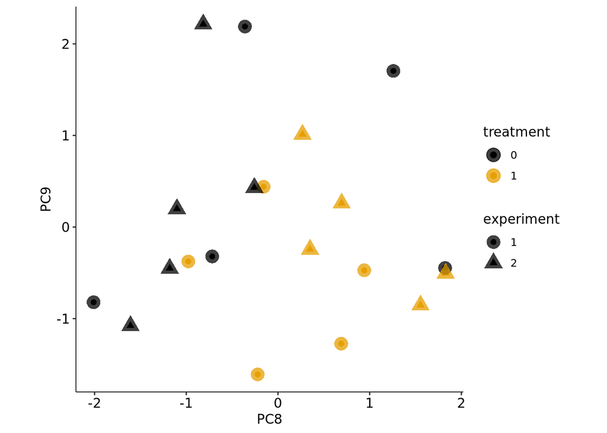

```r
# EXP FUN root PCs 8 & 9
pcaPlot(EXP$FUN$root, c(8, 9), "experiment", "PCA_EXP_FUN_root_PC8-9.png")
```

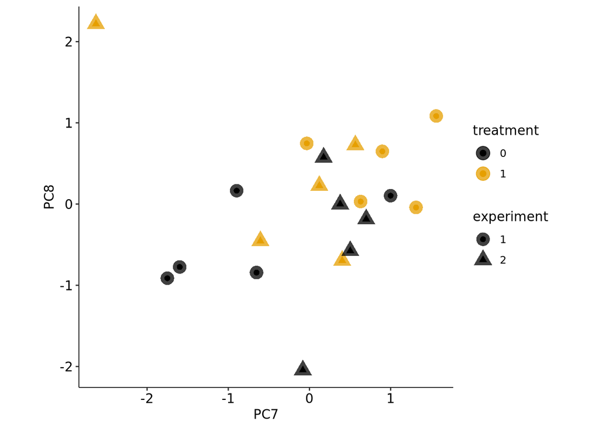

```r
# pcaPlot(EXP$FUN$soil, c(6), "experiment", "PCA_EXP_FUN_soil_PC6.png")

# EXP BAC root PCs 7 & 8
pcaPlot(EXP$BAC$root, c(7, 8), "experiment", "PCA_EXP_BAC_root_PC7-8.png")
```

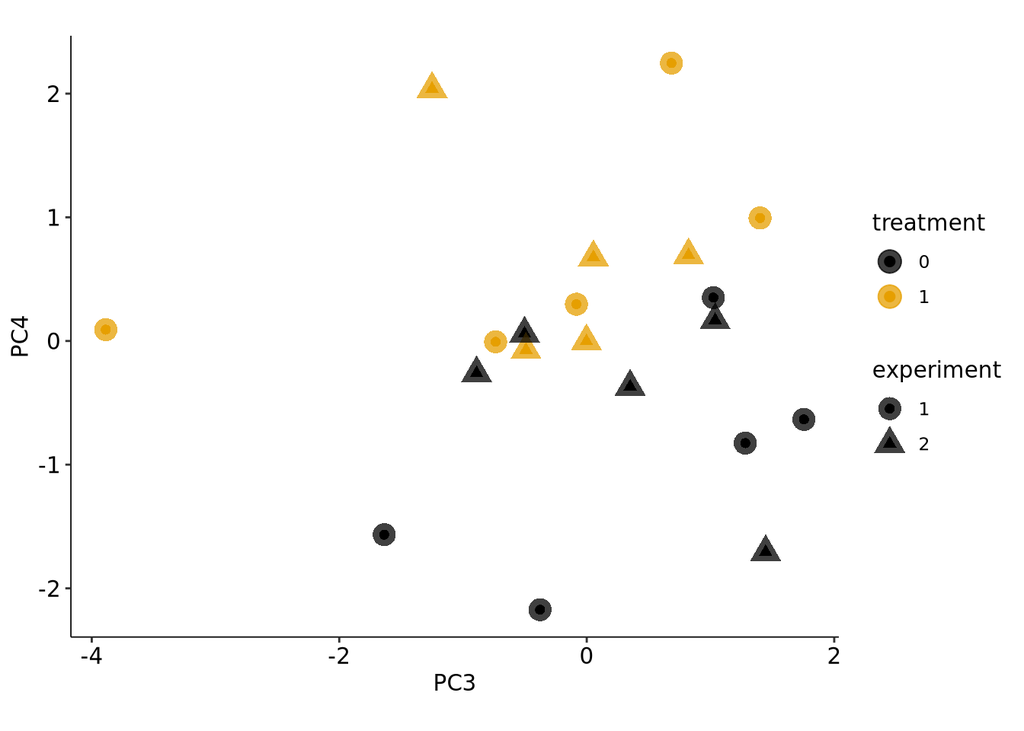

```r
# EXP BAC soil PCs 3 & 4
pcaPlot(EXP$BAC$soil, c(3, 4), "experiment", "PCA_EXP_BAC_soil_PC3-4.png")
```

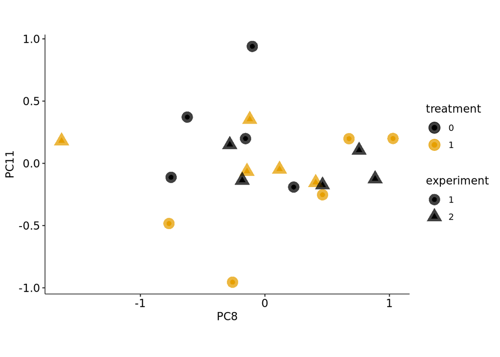

```r
# EXP BAC soil PCs 8 & 11
pcaPlot(EXP$BAC$soil, c(8, 11), "experiment", "PCA_EXP_BAC_soil_PC8-11.png")
```

```r
# TIME FUN
```

Insights

EXP FUN root PCs 8 & 9

EXP BAC root PCs 7 & 8 PC7 exp 1 lest

### 6.3 PC loadings

```r
# PC loadings
pcLoadings <- function(data, pc, top_n = 10) {
  df <- cbind(PC = data$pca$x[, pc], data$colData)
  aggregate(PC ~ treatment, df, mean) |> print()

  loadings <- data$pca$rotation[, pc]
  top_asvs <- names(sort(abs(loadings), decreasing = TRUE))[1:top_n]
  data.table(
    PC = pc,
    ASVs = top_asvs,
    loading = loadings[top_asvs],
    taxa = data$taxData[top_asvs, ]$rank
  )
}

# Fungi root PC8
pcLoadings(EXP$FUN$root, 8, 10) |> printTable()
```

```
##   treatment        PC
## 1         0 -10.24977
## 2         1  10.24977
```

| PC | ASVs | loading | taxa |
| --- | --- | --- | --- |
| 8 | OTU34 | -0.1275787438788512 | Basidiomycota(p) |
| 8 | OTU23 | 0.1178336361346177 | Agaricomycetes(c) |
| 8 | OTU52 | 0.1097804388145005 | Chaetomiaceae(f) |
| 8 | OTU77 | 0.1071733348131754 | Fungi(k) |
| 8 | OTU330 | -0.105650612428905 | Fungi(k) |
| 8 | OTU47 | 0.1031283044208476 | Basidiomycota(p) |
| 8 | OTU323 | 0.09951240132992452 | Hypocreales(o) |
| 8 | OTU101 | 0.0986875535329042 | Fungi(k) |
| 8 | OTU211 | 0.09864403863969541 | Mortierella(g) |
| 8 | OTU260 | -0.09746449903913941 | Basidiomycota(p) |

```r
# Fungi root PC8
pcLoadings(EXP$FUN$root, 9, 10) |> printTable()
```

```
##   treatment        PC
## 1         0  7.718196
## 2         1 -7.718196
```

| PC | ASVs | loading | taxa |
| --- | --- | --- | --- |
| 9 | OTU38 | 0.1633580653309857 | Ascomycota(p) |
| 9 | OTU406 | 0.1388172492639147 | Basidiomycota(p) |
| 9 | OTU516 | 0.1370241951558858 | Basidiomycota(p) |
| 9 | OTU31 | 0.1073866009558237 | Penicillium(g) |
| 9 | OTU749 | 0.1048197176291364 | Fungi(k) |
| 9 | OTU106 | -0.09978299164901713 | Linnemannia(g) |
| 9 | OTU195 | 0.09225790570977335 | Brunneochlamydosporium nepalense(s) |
| 9 | OTU11 | 0.09014719233857778 | Hypocreales(o) |
| 9 | OTU76 | -0.08937257516392617 | Cladosporium(g) |
| 9 | OTU495 | 0.0890548517844155 | Basidiomycota(p) |

```r
# Fungi soil PC6
pcLoadings(EXP$FUN$soil, 6, 10) |> printTable()
```

```
##   treatment        PC
## 1         0  10.46277
## 2         1 -10.46277
```

| PC | ASVs | loading | taxa |
| --- | --- | --- | --- |
| 6 | OTU24 | 0.1293981927161203 | Plectosphaerellaceae(f) |
| 6 | OTU100 | -0.1149874723462452 | Fungi(k) |
| 6 | OTU18 | 0.1013911858556971 | Dactylonectria macrodidyma(s) |
| 6 | OTU353 | -0.09979665449203574 | Trichocladium asperum(s) |
| 6 | OTU1031 | -0.09739729439754347 | Fungi(k) |
| 6 | OTU287 | 0.09712239027014176 | Plectosphaerella(g) |
| 6 | OTU206 | -0.0957503131431539 | Penicillium canescens(s) |
| 6 | OTU555 | 0.08866940236672369 | Arthrographis kalrae(s) |
| 6 | OTU49 | -0.08783113068322812 | Pleosporales(o) |
| 6 | OTU330 | -0.08717016121568034 | Fungi(k) |

```r
# Bacteria root PC7
pcLoadings(EXP$BAC$root, 7, 10) |> printTable()
```

```
##   treatment        PC
## 1         0 -5.582176
## 2         1  5.582176
```

| PC | ASVs | loading | taxa |
| --- | --- | --- | --- |
| 7 | OTU472 | 0.07920616325908406 | Oxalobacteraceae(f) |
| 7 | OTU511 | -0.06936929560167127 | Rhizobiaceae(f) |
| 7 | OTU2001 | 0.06780576488191582 | Jonesiaceae(f) |
| 7 | OTU636 | -0.06483216769558843 | Solirubrobacterales(o) |
| 7 | OTU235 | 0.06445090137974015 | Flavobacterium(g) |
| 7 | OTU2765 | -0.06390039438081077 | Proteobacteria(p) |
| 7 | OTU820 | -0.06358230271945317 | Streptomyces(g) |
| 7 | OTU586 | -0.06202503026251072 | Rhizobium(g) |
| 7 | OTU684 | -0.06147615338110867 | Phyllobacteriaceae(f) |
| 7 | OTU444 | 0.06119342249220799 | Clostridium_sensu_stricto(g) |

```r
# Bacteria soil PC4
pcLoadings(EXP$BAC$soil, 4, 10) |> printTable()
```

```
##   treatment       PC
## 1         0 -14.2388
## 2         1  14.2388
```

| PC | ASVs | loading | taxa |
| --- | --- | --- | --- |
| 4 | OTU40 | 0.08340062966412701 | Geomonas(g) |
| 4 | OTU2141 | 0.06164821438932336 | Actinobacteria(p) |
| 4 | OTU1215 | -0.06050632319880714 | Arthrobacter(g) |
| 4 | OTU472 | 0.06014938346395203 | Oxalobacteraceae(f) |
| 4 | OTU865 | 0.05930558134892105 | Geobacter(g) |
| 4 | OTU1607 | -0.05244685771717065 | Phyllobacteriaceae(f) |
| 4 | OTU1142 | 0.0519674197333503 | Intrasporangiaceae(f) |
| 4 | OTU3650 | 0.05175217683644206 | Bacillaceae_1(f) |
| 4 | OTU1755 | 0.05088737541456972 | Nocardioidaceae(f) |
| 4 | OTU444 | 0.05069123083533875 | Clostridium_sensu_stricto(g) |

```r
# Bacteria soil PC8
pcLoadings(EXP$BAC$soil, 8, 10) |> printTable()
```

```
##   treatment         PC
## 1         0  0.6870756
## 2         1 -0.6870756
```

| PC | ASVs | loading | taxa |
| --- | --- | --- | --- |
| 8 | OTU1663 | 0.06505663285591116 | Micrococcales(o) |
| 8 | OTU2451 | -0.05897254876745604 | Massilia(g) |
| 8 | OTU1215 | 0.05894137248836642 | Arthrobacter(g) |
| 8 | OTU845 | 0.05416297398656107 | Arthrobacter(g) |
| 8 | OTU1840 | -0.05377775153520086 | Bacteria(k) |
| 8 | OTU618 | -0.05320840598968489 | Ilumatobacter(g) |
| 8 | OTU2327 | 0.0520255239473973 | Actinobacteria(p) |
| 8 | OTU322 | 0.05188536413804295 | Trichococcus(g) |
| 8 | OTU1181 | 0.05185154898297865 | Longimicrobia(c) |
| 8 | OTU2894 | 0.0512836223886499 | Longimicrobia(c) |

Note: Multiply absolute loading by proportion of variance in PC explained by treatment can then multiply this by proportion of variance of PC to the total community

## 7 Differential abundance

```r
# Run DESeq model
deseqModel <- function(data, k, s, design) {
  design(data$dds) <- design
  data$dds <- DESeq(data$dds)
  data
}

# Treatment effect with interaction

# e_design <- ~ experiment/block + treatment + experiment:treatment
# t_design <- ~ timepoint + block + treatment + timepoint:treatment

# EXP  <- apply_to_subsets(EXP, deseqModel, e_design)
# TIME <- apply_to_subsets(TIME, deseqModel, t_design)

# resultsNames(EXP$FUN$soil$dds)


# Overall treatment effect

e_design <- ~ experiment/block  + treatment
# t_design <- ~ timepoint + block + treatment

EXP  <- apply_to_subsets(EXP,  deseqModel, e_design)
# TIME <- apply_to_subsets(TIME, deseqModel, t_design)

# resultsNames(EXP$FUN$soil$dds)


# Differential abundance

exp_da  <- apply_to_subsets(EXP, diffAbundanceOverall, "experiment")
# time_da <- apply_to_subsets(TIME, diffAbundanceOverall, "timepoint")


# Analysis per timepoint

design <- ~ block + treatment
time_da <- apply_to_subsets(TIME, diffAbundancePerTimepoint, design)


# exp_da <- split(
#   apply_to_subsets(EXP, diffAbundanceOverall, "experiment") |> combineTables(),
#   f = ~ kingdom
# )

# time_da <- split(
#   apply_to_subsets(TIME, diffAbundanceOverall, "timepoint") |> combineTables(),
#   f = ~ kingdom
# )

# ASV count
cat("Total significant Fungal ASVs: ")
```

```
## Total significant Fungal ASVs:
```

```r
append(bind_rows(exp_da$FUN)$ASV, bind_rows(time_da$FUN)$ASV) |> unique() |> length()
```

```
## [1] 99
```

```r
cat("Total significant Bacterial ASVs: ")
```

```
## Total significant Bacterial ASVs:
```

```r
append(bind_rows(exp_da$BAC)$ASV, bind_rows(time_da$BAC)$ASV) |> unique() |> length()
```

```
## [1] 30
```

```r
printDiffStats <- function(data, type) {
  kingdom <- ifelse(type == "FUN", "Fungal", "Bacterial")
  cat(
    "", kingdom, "soil: ", length(data[[type]]$soil$ASV),
    "\n", kingdom, "root: ", length(data[[type]]$root$ASV),
    "\n", kingdom, "both: ", length(intersect(data[[type]]$soil$ASV, data[[type]]$root$ASV)), "\n"
  )
}
```

### 7.1 Differential abundance tables

#### 7.1.1 EXP: FUN

```r
printDiffStats(exp_da, "FUN")
```

```
##  Fungal soil:  29
##  Fungal root:  55
##  Fungal both:  6
```

```r
exp_da$FUN |> bind_rows() |> printTable()
```

| kingdom | source | ASV | baseMean | log2FC | correlation | padj | sig | taxa |
| --- | --- | --- | --- | --- | --- | --- | --- | --- |
| FUN | root | OTU18 | 5493.689224139306 | -30 | negative | 3.547735041058539e-21 | *** | Dactylonectria macrodidyma(s) |
| FUN | root | OTU23 | 2132.690017786559 | 8.562055795791531 | positive | 0.01718227744278471 | * | Agaricomycetes(c) |
| FUN | root | OTU29 | 1140.518954122068 | 16.43150213715362 | positive | 3.448189659005175e-07 | *** | Dactylonectria macrodidyma(s) |
| FUN | root | OTU195 | 1033.722106333335 | -29.33599692176519 | negative | 2.35841301068761e-20 | *** | Brunneochlamydosporium nepalense(s) |
| FUN | root | OTU24 | 961.9427737176815 | -28.98683177793275 | negative | 4.693402081237933e-20 | *** | Plectosphaerellaceae(f) |
| FUN | root | OTU15 | 907.491525384806 | 23.20522905789363 | positive | 1.868375126207201e-13 | *** | Dactylonectria macrodidyma(s) |
| FUN | root | OTU4 | 813.2985751245571 | -28.44659116153555 | negative | 2.328379476035199e-19 | *** | Plectosphaerellaceae(f) |
| FUN | root | OTU5 | 785.1543769454355 | -27.84107567133114 | negative | 1.349650944252615e-18 | *** | Plectosphaerellaceae(f) |
| FUN | root | OTU43 | 752.5587048320987 | -27.6093303075233 | negative | 2.447760483245219e-18 | *** | Dactylonectria macrodidyma(s) |
| FUN | root | OTU25 | 625.9706062975865 | -27.35626868171715 | negative | 4.767781284414949e-18 | *** | Dactylonectria macrodidyma(s) |

[output cut: 74 more lines]

#### 7.1.2 EXP: BAC

```r
printDiffStats(exp_da, "BAC")
```

```
##  Bacterial soil:  11
##  Bacterial root:  0
##  Bacterial both:  0
```

```r
exp_da$BAC |> bind_rows() |> printTable()
```

| kingdom | source | ASV | baseMean | log2FC | correlation | padj | sig | taxa |
| --- | --- | --- | --- | --- | --- | --- | --- | --- |
| BAC | soil | OTU40 | 288.0165434271573 | 6.778358358304536 | positive | 2.133587032280015e-36 | *** | Geomonas(g) |
| BAC | soil | OTU1 | 147.9190569312759 | 1.748896959248245 | positive | 0.009855632794435557 | ** | Actinobacteria(c) |
| BAC | soil | OTU444 | 64.99839766863232 | 3.711541603092958 | positive | 1.755004927610794e-07 | *** | Clostridium_sensu_stricto(g) |
| BAC | soil | OTU484 | 46.52017773450834 | 2.924776780064764 | positive | 0.0002446964406126978 | *** | Desulfuromonadaceae(f) |
| BAC | soil | OTU472 | 31.03198145651431 | 5.803459534904523 | positive | 6.156178161442397e-15 | *** | Oxalobacteraceae(f) |
| BAC | soil | OTU573 | 27.57183936108776 | 2.28409182377741 | positive | 0.02560400997652391 | * | Comamonadaceae(f) |
| BAC | soil | OTU881 | 23.73769096086593 | 2.774209393217571 | positive | 0.01546440408451924 | * | Intrasporangiaceae(f) |
| BAC | soil | OTU865 | 22.98321613275208 | 3.221217323337817 | positive | 0.009962862935944651 | ** | Geobacter(g) |
| BAC | soil | OTU1307 | 19.24983709502593 | 3.090411162677947 | positive | 0.005478138151112987 | ** | Geobacter(g) |
| BAC | soil | OTU2112 | 10.50685951472651 | 5.480818952471283 | positive | 5.29834309541268e-05 | *** | Geomonas(g) |

[output cut: 1 more lines]

#### 7.1.3 TIME: FUN

```r
printDiffStats(time_da, "FUN")
```

```
##  Fungal soil:  25
##  Fungal root:  43
##  Fungal both:  12
```

```r
time_da$FUN |> bind_rows() |> printTable()
```

| ASV | T1_baseMean | T1_log2FoldChange | T1_lfcSE | T1_stat | T1_pvalue | T1_padj | T1_stars | T2_baseMean | T2_log2FoldChange | T2_lfcSE | T2_stat | T2_pvalue | T2_padj | T2_stars | source | baseMean | sig | taxa |
| --- | --- | --- | --- | --- | --- | --- | --- | --- | --- | --- | --- | --- | --- | --- | --- | --- | --- | --- |
| OTU18 | 12746.46893618741 | -30 | 3.132400589368774 | -9.57731910210292 | 9.959656058532284e-22 | 6.169895449008059e-20 | *** | 2139.731995267231 | 21.62613028086357 | 3.132400649696927 | 6.904011555148923 | 5.055418499916069e-12 | 1.280706019978738e-10 | *** | root | 7443.100465727321 | Both | Dactylonectria macrodidyma(s) |
| OTU28 | 509.1310523882074 | 20.05415812731615 | 3.132402538362445 | 6.402165073522141 | 1.531889080788293e-10 | 5.259485844039804e-10 | *** | 4980.906867030361 | -30 | 3.132402219665166 | -9.577314117472058 | 9.960136614318483e-22 | 7.569703826882048e-20 | *** | root | 2745.018959709284 | Both | Dactylonectria macrodidyma(s) |
| OTU19 | 4397.446489032143 | 8.431704471532223 | 2.947932138800421 | 2.860209826595014 | 0.004233607922192889 | 0.01245890331388193 | * | 69.22273753316975 | 1.927435450106859 | 2.090943858204083 | 0.9218016268319792 | 0.3566320587348719 | 0.8541705846913423 |  | root | 2233.334613282656 | T1 | Cadophora luteo-olivacea(s) |
| OTU22 | 3564.01066600672 | 22.26153451091825 | 3.132402822626204 | 7.106855590257128 | 1.18716534671435e-12 | 5.558092305071731e-12 | *** | 0 |  |  |  |  |  |  | root | 1782.00533300336 | T1 | Dactylonectria macrodidyma(s) |
| OTU15 | 1319.296251611664 | 21.47032953521982 | 3.13240157623468 | 6.854271080091953 | 7.167704978385259e-12 | 3.076140053223674e-11 | *** | 1757.012044947342 | -28.91989509572633 | 3.132400444737042 | -9.232502550660978 | 2.643814243203531e-20 | 1.004649412417342e-18 | *** | root | 1538.154148279503 | Both | Dactylonectria macrodidyma(s) |
| OTU10 | 2811.930769673429 | 22.08130599224587 | 3.13240368611654 | 7.049316820215343 | 1.797983544791293e-12 | 8.051839352761009e-12 | *** | 0 |  |  |  |  |  |  | root | 1405.965384836715 | T1 | Plectosphaerellaceae(f) |
| OTU195 | 2448.78469149695 | -28.58354751048811 | 3.13240730926732 | -9.125105609964205 | 7.16663494295099e-20 | 1.84540849780988e-18 | *** | 0.2593220225432453 | -1.821690324581785 | 3.117789001305389 | -0.5842891625504676 | 0.559025782273167 |  |  | root | 1224.522006759747 | T1 | Brunneochlamydosporium nepalense(s) |
| OTU24 | 2273.255606453805 | -29.03885209466644 | 3.132405354245155 | -9.27046432713821 | 1.853373167837632e-20 | 6.363247876242536e-19 | *** | 7.579240914688782 | -0.6697097441587854 | 3.095942603766228 | -0.2163185271406778 | 0.8287394683659356 |  |  | root | 1140.417423684247 | T1 | Plectosphaerellaceae(f) |
| OTU4 | 1926.623304444537 | -28.04094026148628 | 3.13240177597932 | -8.951897702432985 | 3.494226984013085e-19 | 5.998422989222463e-18 | *** | 0.7486110194548281 | -2.327470530143893 | 3.130815645439402 | -0.7434070842000148 | 0.4572352566022684 |  |  | root | 963.685957731996 | T1 | Plectosphaerellaceae(f) |
| OTU5 | 1859.95250265628 | -27.30942342061123 | 3.132401966777651 | -8.71836491939917 | 2.822480149477894e-18 | 3.230171726624701e-17 | *** | 1.307762869077226 | -0.003375206833069869 | 3.092041840677643 | -0.001091578641875742 | 0.9991290464277084 |  |  | root | 930.6301327626786 | T1 | Plectosphaerellaceae(f) |

[output cut: 58 more lines]

#### 7.1.4 TIME: BAC

```r
printDiffStats(time_da, "FUN")
```

[output not shown]

```r
time_da$BAC |> bind_rows() |> printTable()
```

| ASV | T1_baseMean | T1_log2FoldChange | T1_lfcSE | T1_stat | T1_pvalue | T1_padj | T1_stars | T2_baseMean | T2_log2FoldChange | T2_lfcSE | T2_stat | T2_pvalue | T2_padj | T2_stars | source | baseMean | sig | taxa |
| --- | --- | --- | --- | --- | --- | --- | --- | --- | --- | --- | --- | --- | --- | --- | --- | --- | --- | --- |
| OTU34 | 530.8591392727914 | -3.001181011841117 | 0.7209945521035351 | -4.162557127630205 | 3.14703373235228e-05 | 0.003091355443241432 | ** | 91.0218811142499 | -1.250837711639732 | 0.8730751817835558 | -1.432680412567067 | 0.1519491896736484 | 0.9994291232446945 |  | root | 310.9405101935207 | T1 | Rhizobiaceae(f) |
| OTU52 | 273.9996416236717 | -3.545339965886896 | 0.5837222253130291 | -6.073676505953938 | 1.250144467581801e-09 | 7.20033623373968e-07 | *** | 66.5874603392696 | -2.072803743328435 | 1.232477063375074 | -1.68181932542596 | 0.09260388011762283 | 0.9994291232446945 |  | root | 170.2935509814706 | T1 | Cellvibrio(g) |
| OTU111 | 280.7845704082287 | 3.951223419595436 | 0.6882062921584263 | 5.741335795119201 | 9.39326153016549e-09 | 2.998798743505332e-06 | *** | 17.15220985014776 | 1.505934800645928 | 1.038957266443652 | 1.449467508707782 | 0.1472070676779519 | 0.9994291232446945 |  | root | 148.9683901291882 | T1 | Cellulomonas(g) |
| OTU40 | 124.9355525073736 | 7.050242074821497 | 1.105924108517516 | 6.374978192918046 | 1.829889873096673e-10 | 2.336769367944452e-07 | *** | 10.11688828059465 | 6.676083237295867 | 1.703072049783616 | 3.920023957967073 | 8.854016628152974e-05 | 0.06565419240834622 | . | root | 67.5262203939841 | T1 | Geomonas(g) |
| OTU259 | 69.4885277555382 | -3.685854285508188 | 0.8072510357160172 | -4.565933176213148 | 4.972771716224523e-06 | 0.000577293589238065 | *** | 48.52006632148382 | -0.8647001932774104 | 0.9571354399312951 | -0.9034251133146634 | 0.3663003164976608 | 0.9994291232446945 |  | root | 59.00429703851101 | T1 | Devosia(g) |
| OTU684 | 86.18816405867615 | -3.166157029252623 | 0.7701242068218608 | -4.11122907344866 | 3.935584928740491e-05 | 0.00358981568142972 | ** | 9.396829322943422 | -1.423116349428975 | 1.746764539441564 | -0.8147156169565601 | 0.4152351119781961 | 0.9994291232446945 |  | root | 47.79249669080978 | T1 | Phyllobacteriaceae(f) |
| OTU511 | 74.268838860725 | -4.160000680122083 | 1.059476653952752 | -3.926467529606934 | 8.620252311126805e-05 | 0.007338708134205954 | ** | 18.27366995240444 | -2.153474905206063 | 1.600532976747215 | -1.345473624406414 | 0.1784723333274896 | 0.9994291232446945 |  | root | 46.27125440656472 | T1 | Rhizobiaceae(f) |
| OTU491 | 52.32196874175274 | 6.120929588999043 | 1.602329847910748 | 3.820018454365076 | 0.0001334416896021015 | 0.009534088192870072 | ** | 31.70651161557107 | 0.1899085329067807 | 1.862975784832919 | 0.1019382723344483 | 0.9188056712490503 | 0.9994291232446945 |  | root | 42.01424017866191 | T1 | Acidobacteria_Gp10(c) |
| OTU423 | 68.17270347710897 | 7.879312623356831 | 1.438592626715403 | 5.477097878185913 | 4.323580905954957e-08 | 8.422253832036294e-06 | *** | 9.267265585687163 | 6.436678761194886 | 1.720651515075679 | 3.740838109750412 | 0.0001834076342308943 | 0.07471800722707478 | . | root | 38.71998453139807 | T1 | Eubacteriaceae(f) |
| OTU322 | 65.40494837816158 | 7.169268905515507 | 1.259235278093984 | 5.69335137780378 | 1.245696526578784e-08 | 3.181508928882215e-06 | *** | 0 |  |  |  |  |  |  | root | 32.70247418908079 | T1 | Trichococcus(g) |

[output cut: 23 more lines]

### 7.2 Differential abundance subsets

```r
bind_rows(exp_da$FUN)  |> select("taxa") |> table() |> as.data.table() |> printTable()
```

| taxa | N |
| --- | --- |
| Acrostalagmus luteoalbus(s) | 1 |
| Agaricomycetes(c) | 1 |
| Ascomycota(p) | 4 |
| Basidiomycota(p) | 2 |
| Brunneochlamydosporium nepalense(s) | 2 |
| Ceratobasidiaceae(f) | 1 |
| Chaetomiaceae(f) | 1 |
| Chaetomium(g) | 1 |
| Dactylonectria macrodidyma(s) | 8 |
| Didymellaceae(f) | 1 |

[output cut: 21 more lines]

```r
bind_rows(time_da$FUN) |> select("taxa") |> table() |> as.data.table() |> printTable()
```

| taxa | N |
| --- | --- |
| Ascomycota(p) | 2 |
| Basidiomycota(p) | 1 |
| Brunneochlamydosporium nepalense(s) | 1 |
| Cadophora luteo-olivacea(s) | 1 |
| Ceratobasidiaceae(f) | 1 |
| Chaetomium(g) | 1 |
| Dactylonectria macrodidyma(s) | 12 |
| Didymellaceae(f) | 1 |
| Fungi(k) | 6 |
| Fusarium(g) | 6 |

[output cut: 13 more lines]

```r
bind_rows(exp_da$FUN)[grepl("Dactylonectria", taxa)] |> printTable()
```

| kingdom | source | ASV | baseMean | log2FC | correlation | padj | sig | taxa |
| --- | --- | --- | --- | --- | --- | --- | --- | --- |
| FUN | root | OTU18 | 5493.689224139306 | -30 | negative | 3.547735041058539e-21 | *** | Dactylonectria macrodidyma(s) |
| FUN | root | OTU29 | 1140.518954122068 | 16.43150213715362 | positive | 3.448189659005175e-07 | *** | Dactylonectria macrodidyma(s) |
| FUN | root | OTU15 | 907.491525384806 | 23.20522905789363 | positive | 1.868375126207201e-13 | *** | Dactylonectria macrodidyma(s) |
| FUN | root | OTU43 | 752.5587048320987 | -27.6093303075233 | negative | 2.447760483245219e-18 | *** | Dactylonectria macrodidyma(s) |
| FUN | root | OTU25 | 625.9706062975865 | -27.35626868171715 | negative | 4.767781284414949e-18 | *** | Dactylonectria macrodidyma(s) |
| FUN | root | OTU28 | 214.9229475755651 | 19.81859346566414 | positive | 4.949665672520437e-10 | *** | Dactylonectria macrodidyma(s) |
| FUN | soil | OTU22 | 252.1552641929896 | -30 | negative | 5.084241238985588e-21 | *** | Dactylonectria macrodidyma(s) |
| FUN | soil | OTU15 | 96.89112893575947 | -24.4326004652159 | negative | 3.093311250919135e-14 | *** | Dactylonectria macrodidyma(s) |

```r
bind_rows(time_da$FUN)[grepl("Pleosporales", taxa)]  |> printTable()
```

| ASV | T1_baseMean | T1_log2FoldChange | T1_lfcSE | T1_stat | T1_pvalue | T1_padj | T1_stars | T2_baseMean | T2_log2FoldChange | T2_lfcSE | T2_stat | T2_pvalue | T2_padj | T2_stars | source | baseMean | sig | taxa |
| --- | --- | --- | --- | --- | --- | --- | --- | --- | --- | --- | --- | --- | --- | --- | --- | --- | --- | --- |

```r
bind_rows(exp_da$BAC)  |> select("taxa") |> table() |> as.data.table() |> printTable()
```

| taxa | N |
| --- | --- |
| Actinobacteria(c) | 1 |
| Clostridium_sensu_stricto(g) | 1 |
| Comamonadaceae(f) | 2 |
| Desulfuromonadaceae(f) | 1 |
| Geobacter(g) | 2 |
| Geomonas(g) | 2 |
| Intrasporangiaceae(f) | 1 |
| Oxalobacteraceae(f) | 1 |

```r
bind_rows(time_da$BAC) |> select("taxa") |> table() |> as.data.table() |> printTable()
```

| taxa | N |
| --- | --- |
| Acidobacteria_Gp10(c) | 1 |
| Actinobacteria(c) | 1 |
| Actinotalea(g) | 1 |
| Arenibacter(g) | 1 |
| Arenimonas(g) | 1 |
| Cellulomonas(g) | 1 |
| Cellvibrio(g) | 2 |
| Clostridium_sensu_stricto(g) | 3 |
| Comamonadaceae(f) | 2 |
| Desulfuromonadaceae(f) | 1 |

[output cut: 10 more lines]

```r
bind_rows(time_da$BAC)[grepl("Oxalobacteraceae", taxa)] |> printTable()
```

| ASV | T1_baseMean | T1_log2FoldChange | T1_lfcSE | T1_stat | T1_pvalue | T1_padj | T1_stars | T2_baseMean | T2_log2FoldChange | T2_lfcSE | T2_stat | T2_pvalue | T2_padj | T2_stars | source | baseMean | sig | taxa |
| --- | --- | --- | --- | --- | --- | --- | --- | --- | --- | --- | --- | --- | --- | --- | --- | --- | --- | --- |
| OTU472 | 51.06327918740595 | 8.39487059330174 | 1.393349405655263 | 6.02495724276267 | 1.69154335953164e-09 | 7.20033623373968e-07 | *** | 1.377266331263487 | 3.355871020765276 | 3.061749082246243 | 1.09606337117059 | 0.2730510428076645 | 0.9994291232446945 |  | root | 26.22027275933472 | T1 | Oxalobacteraceae(f) |
| OTU1489 | 19.60573358227621 | 7.022017688136978 | 1.528821275265346 | 4.593092601303718 | 4.367251514931601e-06 | 0.0005576980184567655 | *** | 0.2798229312592558 | 0.7130435003086291 | 3.117059169547934 | 0.2287552021067478 | 0.8190591870759932 | 0.9994291232446945 |  | root | 9.942778256767733 | T1 | Oxalobacteraceae(f) |
| OTU472 | 51.96779731900131 | 5.317656925687183 | 0.8757927875939274 | 6.071820870204269 | 1.264679600478098e-09 | 6.14950455732475e-07 | *** | 9.023578129551774 | 6.377784014612676 | 1.50619784333563 | 4.234360076156009 | 2.292034427925016e-05 | 0.02342459185339366 | * | soil | 30.49568772427654 | Both | Oxalobacteraceae(f) |
| OTU1489 | 21.56717723315613 | 7.004500399695167 | 1.36536337941383 | 5.130136420314935 | 2.895322725706232e-07 | 0.0001126280540299724 | *** | 1.69095960796896 | 2.848677066634198 | 3.087668011623796 | 0.9225982378643376 | 0.3562166143286036 | 0.9997509529053201 |  | soil | 11.62906842056254 | T1 | Oxalobacteraceae(f) |
| OTU1811 | 19.48749415259926 | 6.353252690349874 | 1.424971142448555 | 4.458513229561238 | 8.253010408115691e-06 | 0.002293157891969288 | ** | 0.4415321938047384 | 1.060840507416474 | 3.114016788972532 | 0.3406662774501281 | 0.7333548283531708 | 0.9997509529053201 |  | soil | 9.964513173201999 | T1 | Oxalobacteraceae(f) |

The fungal taxa with multiple occurences (but different ASVs) had wildly different results. There were fewer bacteria with multiple occurences, but the results were more consistant.

### 7.3 Differential abundace at genus level

- Filter dds by genus at 50% confidence
- Group by genus
- Run DESeq analysis on genus counts

```r
# Filter dds by genus at 50% confidence

diffAbundanceGenus <- function(data, k, s, sample_min = 4, tax_conf = 0.5) {
  # Filter ASVs with genus at tax_conf confidence
  taxData <- data$taxData[data$taxData$g_conf >= tax_conf, ]
  countData <- counts(data$dds)[rownames(taxData), ]

  # Sum counts per genus
  countData <- rowsum(countData, group = taxData$genus)

  # Filter Genera present in >= sample_min samples
  countData <- countData[rowSums(countData > 0) >= sample_min, ]
  taxData <- taxData[rownames(countData), ]

  # Rename
  rownames(countData) <- gsub("_sensu_stricto", "", rownames(countData))
  taxData$genus <- gsub("_sensu_stricto", "", taxData$genus)

  # Create dds object
  dds <- DESeqDataSetFromMatrix(countData, data$colData, ~ 1)
  sizeFactors(dds) <- sizeFactors(data$dds)
  list(taxData = taxData, countData = countData, colData = data$colData, dds = dds)
}

# diffAbundanceGenus(EXP$FUN$soil, "FUN", "soil")

EXP_genus  <- apply_to_subsets(EXP,  diffAbundanceGenus)
TIME_genus <- apply_to_subsets(TIME, diffAbundanceGenus)

e_design <- ~ experiment/block  + treatment
EXP_genus <- apply_to_subsets(EXP_genus,  deseqModel, e_design)
exp_genus_da  <- apply_to_subsets(EXP_genus, diffAbundanceOverall, "experiment")

t_design <- ~ block + treatment
time_genus_da <- apply_to_subsets(TIME_genus, diffAbundancePerTimepoint, t_design)
```

### 7.4 Differential abundance at genus tables

#### 7.4.1 EXP: FUN

```r
printDiffStats(exp_genus_da, "FUN")
```

```
##  Fungal soil:  0
##  Fungal root:  2
##  Fungal both:  0
```

```r
exp_genus_da$FUN |> bind_rows() |> printTable()
```

| kingdom | source | ASV | baseMean | log2FC | correlation | padj | sig | taxa |
| --- | --- | --- | --- | --- | --- | --- | --- | --- |
| FUN | root | Juxtiphoma | 494.1959617063749 | -29.30450165098213 | negative | 1.046278670270307e-20 | *** |  |
| FUN | root | Serendipita | 185.705170878974 | 11.34297868993491 | positive | 0.004438684515765937 | ** |  |

#### 7.4.2 EXP: BAC

```r
printDiffStats(exp_genus_da, "BAC")
```

```
##  Bacterial soil:  4
##  Bacterial root:  4
##  Bacterial both:  1
```

```r
exp_genus_da$BAC |> bind_rows() |> printTable()
```

| kingdom | source | ASV | baseMean | log2FC | correlation | padj | sig | taxa |
| --- | --- | --- | --- | --- | --- | --- | --- | --- |
| BAC | root | Cellulomonas | 155.1802502411836 | 2.667219459973559 | positive | 0.01110503396343855 | * |  |
| BAC | root | Geomonas | 69.53264222103809 | 5.915140589092924 | positive | 5.674884983034898e-05 | *** |  |
| BAC | root | Arenibacter | 36.45418157241105 | -4.004659872409159 | negative | 0.00501370585589934 | ** |  |
| BAC | root | Lysinimonas | 14.28715790922883 | -7.513761714764644 | negative | 0.008064119226442165 | ** |  |
| BAC | soil | Geomonas | 340.081797700568 | 5.409047145555163 | positive | 1.673190149728806e-15 | *** |  |
| BAC | soil | Clostridium | 124.4630812808679 | 1.846096447564052 | positive | 1.035390579602347e-05 | *** |  |
| BAC | soil | Desulfuromonas | 54.67834986239206 | 2.879466602822272 | positive | 0.01373723852159825 | * |  |
| BAC | soil | Geobacter | 50.42426129099146 | 3.086367035996267 | positive | 0.001358392417046365 | ** |  |

#### 7.4.3 TIME: FUN

```r
printDiffStats(time_genus_da, "FUN")
```

```
##  Fungal soil:  4
##  Fungal root:  6
##  Fungal both:  1
```

```r
time_genus_da$FUN |> bind_rows() |> printTable()
```

| ASV | T1_baseMean | T1_log2FoldChange | T1_lfcSE | T1_stat | T1_pvalue | T1_padj | T1_stars | T2_baseMean | T2_log2FoldChange | T2_lfcSE | T2_stat | T2_pvalue | T2_padj | T2_stars | source | baseMean | sig | taxa |
| --- | --- | --- | --- | --- | --- | --- | --- | --- | --- | --- | --- | --- | --- | --- | --- | --- | --- | --- |
| Gibellulopsis | 13120.44569918402 | -2.766921998143521 | 0.879658200321154 | -3.145451264062959 | 0.001658308217738847 | 0.0259801620779086 | * | 116.59332981992 | -1.511787255752669 | 1.194283838691581 | -1.26585256098662 | 0.2055658731420397 | 0.862406628761853 |  | root | 6618.519514501972 | T1 |  |
| Plectosphaerella | 1902.17901527579 | -0.8274559658384638 | 0.9900763028476516 | -0.8357496926838264 | 0.4032957332259822 | 0.5265249850450323 |  | 477.030193716011 | -4.46833880115926 | 1.468063740334989 | -3.04369536443946 | 0.002336916504894749 | 0.03739066407831598 | * | root | 1189.604604495901 | T2 |  |
| Juxtiphoma | 1169.694339519833 | -27.87404478941651 | 3.093188332179022 | -9.011428272710575 | 2.033900944777419e-19 | 9.559334440453869e-18 | *** | 6.324541302450973 | -2.923109532972882 | 3.064585530023809 | -0.9538351938084668 | 0.3401670716702192 | 0.9604717317747367 |  | root | 588.009440411142 | T1 |  |
| Thelonectria | 478.2810785580894 | 0.3231310466421916 | 1.561825573565381 | 0.2068931717544736 | 0.8360932893003683 | 0.8732529910470513 |  | 518.3972111074656 | 6.962940337067642 | 1.427599895819323 | 4.877375206777734 | 1.075068200808434e-06 | 5.160327363880483e-05 | *** | root | 498.3391448327775 | T2 |  |
| Rhizoctonia | 0 |  |  |  |  |  |  | 252.4466038404414 | -13.55156815002303 | 2.950329297097063 | -4.593239189726012 | 4.364183575062286e-06 | 0.0001047404058014949 | *** | root | 126.2233019202207 | T2 |  |
| Cephalotrichum | 106.6306000011511 | -5.44480718343702 | 1.602756447460021 | -3.397151945366195 | 0.000680911469918114 | 0.01600141954307568 | * | 77.42245652162175 | -1.779459819122531 | 3.084372291523362 | -0.5769277022793061 | 0.5639882959107617 | 0.9819551416649661 |  | root | 92.02652826138643 | T1 |  |
| Thelonectria | 1190.066279214986 | 0.9635435004466524 | 0.8047630300293752 | 1.197300900379931 | 0.2311892936231131 | 0.9755170224235548 |  | 2072.885325352457 | 5.438635286276198 | 1.026416897597003 | 5.298661098632403 | 1.166549255694844e-07 | 9.332394045558754e-06 | *** | soil | 1631.475802283722 | T2 |  |
| Cadophora | 98.80672792832667 | 5.614370787132294 | 1.395038252772153 | 4.024528199119763 | 5.708965337783837e-05 | 0.004452992963471393 | ** | 872.3334128602959 | 0.8238181383893528 | 1.163854599971872 | 0.7078359602730985 | 0.479047132151481 | 0.981850147105905 |  | soil | 485.5700703943113 | T1 |  |
| Chaetomium | 69.66449439747093 | 5.539136156506474 | 1.654833995527202 | 3.347245809234055 | 0.0008161880223469181 | 0.0318313328715298 | * | 75.16618537801878 | 2.875902381842551 | 1.481914441855755 | 1.940666951218282 | 0.0522986874951873 | 0.5388441275203829 |  | soil | 72.41533988774486 | T1 |  |
| Hirsutella | 2.302138043549794 | -0.6569498759405148 | 3.111545054572448 | -0.2111330109056657 | 0.8327834818110255 | 0.9755170224235548 |  | 123.1941724000768 | 6.953964163596781 | 1.619502250201977 | 4.293889781708863 | 1.755696584090767e-05 | 0.000702278633636307 | *** | soil | 62.74815522181328 | T2 |  |

#### 7.4.4 TIME: BAC

```r
printDiffStats(time_genus_da, "BAC")
```

```
##  Bacterial soil:  6
##  Bacterial root:  10
##  Bacterial both:  4
```

```r
time_genus_da$BAC |> bind_rows() |> printTable()
```

| ASV | T1_baseMean | T1_log2FoldChange | T1_lfcSE | T1_stat | T1_pvalue | T1_padj | T1_stars | T2_baseMean | T2_log2FoldChange | T2_lfcSE | T2_stat | T2_pvalue | T2_padj | T2_stars | source | baseMean | sig | taxa |
| --- | --- | --- | --- | --- | --- | --- | --- | --- | --- | --- | --- | --- | --- | --- | --- | --- | --- | --- |
| Cellvibrio | 352.8647826361662 | -3.152707852789083 | 0.5053180127412541 | -6.239056937009316 | 4.402167530254554e-10 | 2.388175885163095e-08 | *** | 108.6274474217585 | -0.8585540418498351 | 0.7641516722451727 | -1.123538785601681 | 0.2612087376793209 | 0.9435633695868166 |  | root | 230.7461150289624 | T1 |  |
| Cellulomonas | 296.9098276976952 | 4.030569460479327 | 0.5946796307287584 | 6.777715684561131 | 1.220908085585059e-11 | 1.324685272859789e-09 | *** | 20.84759333862963 | 1.478687829334655 | 0.9934242795068525 | 1.488475629032032 | 0.1366255046243752 | 0.7809957307317895 |  | root | 158.8787105181624 | T1 |  |
| Geomonas | 130.4352018045883 | 6.932375209076191 | 0.9132437341631516 | 7.590936515352776 | 3.176015423967265e-14 | 6.891953470008966e-12 | *** | 10.11688828059465 | 6.674456103405631 | 1.674299321812566 | 3.986417492052726 | 6.707843893789678e-05 | 0.01576343315040574 | * | root | 70.27604504259146 | Both |  |
| Duganella | 74.57241156604053 | 3.189675692655933 | 0.9120316734320002 | 3.497329956374317 | 0.0004699401973670532 | 0.01019770228286505 | * | 29.26170097838343 | -1.988292459607793 | 1.2488117027405 | -1.592147523317176 | 0.1113515610903181 | 0.7490868082762709 |  | root | 51.91705627221198 | T1 |  |
| Clostridium | 62.10490189695069 | 4.433426472196114 | 0.8881255389584705 | 4.991891661392056 | 5.979079169593315e-07 | 2.594920359603498e-05 | *** | 3.635846147363258 | 4.011023522981068 | 2.234493288878922 | 1.795048364183478 | 0.07264599460663139 | 0.7057095166375146 |  | root | 32.87037402215697 | T1 |  |
| Trichococcus | 65.40494837816158 | 7.126537304933823 | 1.118876857701795 | 6.36936697356663 | 1.898099647073559e-10 | 1.372958744716541e-08 | *** | 0 |  |  |  |  |  |  | root | 32.70247418908079 | T1 |  |
| Actinotalea | 50.97808305519937 | 3.567851567419521 | 0.8785410558055236 | 4.061109658840247 | 4.884002296368946e-05 | 0.001324785622890077 | ** | 3.806847638880305 | 2.107574297748196 | 2.621375813819841 | 0.8039954769694245 | 0.4213995871886825 | 0.9918866885993332 |  | root | 27.39246534703984 | T1 |  |
| Arenibacter | 49.76836875524004 | -4.103227865708344 | 0.9853390673654966 | -4.164280095662049 | 3.123364943162652e-05 | 0.0009682431323804222 | *** | 3.272868531357132 | -2.939737895852269 | 2.681163619757141 | -1.09644106543507 | 0.2728858011111073 | 0.9435633695868166 |  | root | 26.52061864329859 | T1 |  |
| Massilia | 44.54956607852205 | 3.386450387638633 | 0.9517387003915567 | 3.558172412496631 | 0.0003734441649757573 | 0.009004153755526592 | ** | 1.826681772384471 | 2.053390857523076 | 3.058293604632454 | 0.6714171766938161 | 0.5019548055683245 | 0.9918866885993332 |  | root | 23.18812392545326 | T1 |  |
| Sanguibacter | 20.46371345821007 | 7.065283766582954 | 1.492290506371494 | 4.734523027799861 | 2.195708423738947e-06 | 7.94114546585586e-05 | *** | 0 |  |  |  |  |  |  | root | 10.23185672910503 | T1 |  |

[output cut: 6 more lines]

### 7.5 Full taxonomies

```r
fullTaxa <- function(taxData, data) {
  cols <- c("kingdom", "phylum", "class", "order", "family", "genus")
  genera <- c(data$root$ASV, data$soil$ASV) |> unique()
  as.data.table(taxData)[genus %in% genera, ..cols] |> unique()
}


bind_rows(
  fullTaxa(FUN$taxData, exp_genus_da$FUN),
  fullTaxa(FUN$taxData, time_genus_da$FUN)
)[order(phylum, class, order, family), ] |> unique() |> printTable()
```

| kingdom | phylum | class | order | family | genus |
| --- | --- | --- | --- | --- | --- |
| Fungi | Ascomycota | Dothideomycetes | Pleosporales | Didymellaceae | Juxtiphoma |
| Fungi | Ascomycota | Leotiomycetes | Helotiales | Helotiales(o) | Cadophora |
| Fungi | Ascomycota | Sordariomycetes | Glomerellales | Plectosphaerellaceae | Gibellulopsis |
| Fungi | Ascomycota | Sordariomycetes | Glomerellales | Plectosphaerellaceae | Plectosphaerella |
| Fungi | Ascomycota | Sordariomycetes | Hypocreales | Nectriaceae | Thelonectria |
| Fungi | Ascomycota | Sordariomycetes | Hypocreales | Ophiocordycipitaceae | Hirsutella |
| Fungi | Ascomycota | Sordariomycetes | Microascales | Microascaceae | Cephalotrichum |
| Fungi | Ascomycota | Sordariomycetes | Sordariales | Chaetomiaceae | Chaetomium |
| Fungi | Basidiomycota | Agaricomycetes | Cantharellales | Ceratobasidiaceae | Rhizoctonia |
| Fungi | Basidiomycota | Agaricomycetes | Sebacinales | Serendipitaceae | Serendipita |

```r
bind_rows(
  fullTaxa(BAC$taxData, exp_genus_da$BAC),
  fullTaxa(BAC$taxData, time_genus_da$BAC)
)[order(phylum, class, order, family), ] |> unique() |> printTable()
```

| kingdom | phylum | class | order | family | genus |
| --- | --- | --- | --- | --- | --- |
| Bacteria | Actinobacteria | Actinobacteria | Micrococcales | Cellulomonadaceae | Cellulomonas |
| Bacteria | Actinobacteria | Actinobacteria | Micrococcales | Cellulomonadaceae | Actinotalea |
| Bacteria | Actinobacteria | Actinobacteria | Micrococcales | Jonesiaceae | Sanguibacter |
| Bacteria | Actinobacteria | Actinobacteria | Micrococcales | Microbacteriaceae | Lysinimonas |
| Bacteria | Bacteroidetes | Flavobacteriia | Flavobacteriales | Flavobacteriaceae | Arenibacter |
| Bacteria | Firmicutes | Bacilli | Lactobacillales | Carnobacteriaceae | Trichococcus |
| Bacteria | Proteobacteria | Betaproteobacteria | Burkholderiales | Comamonadaceae | Ramlibacter |
| Bacteria | Proteobacteria | Betaproteobacteria | Burkholderiales | Oxalobacteraceae | Massilia |
| Bacteria | Proteobacteria | Betaproteobacteria | Burkholderiales | Oxalobacteraceae | Duganella |
| Bacteria | Proteobacteria | Deltaproteobacteria | Desulfuromonadales | Desulfuromonadaceae | Desulfuromonas |

[output cut: 3 more lines]

### 7.6 Differential abundance plots

Heatmaps of abundance of each significant ASV in each sample

```r
# diffAbundanceHeatmap(EXP_genus$FUN$root, exp_genus_da$FUN$root$ASV, "experiment", FALSE, TRUE)

# agg_png(here(FIGURES_DIR, "heatmap_test.png"), width = 22, height = 15, units = "cm")
# diffAbundanceHeatmap(EXP$FUN$soil, exp_da$FUN$soil$ASV, "experiment", FALSE, FALSE) #|> draw()
# dev.off()

# agg_png(here(FIGURES_DIR, "genus_diff_BAC_root.png"), width = 20, height = 10, units = "cm")
# diffAbundanceHeatmap(EXP_genus$BAC$root, exp_genus_da$BAC$root$ASV, "experiment", FALSE, TRUE) #|> draw()
# dev.off()



# agg_png(here(FIGURES_DIR, "heatmap_test.png"))
# diffAbundanceHeatmap(TIME_genus$BAC$soil, time_genus_da$BAC$soil$ASV, "timepoint", FALSE, TRUE) #|> draw()
# dev.off()



#' @title Differential abundance heatmap
#'
diffAbundanceHeatmapCombined <- function(data, ASVs, type, use_log1p = FALSE, genus = FALSE) {
  # Verify input lists
  stopifnot(is.list(data), all(c("soil","root") %in% names(data)))
  stopifnot(is.list(ASVs), all(c("soil","root") %in% names(ASVs)))

  # Prepare data for root and soil
  dat <- lapply(names(data), function(source) {
    # Filter dds matrix for ASVs
    mat <- counts(data[[source]]$dds, normalize = TRUE)[ASVs[[source]]$ASV, ]
    if (use_log1p) mat <- log1p(mat)
    mat[mat == 0] <- NA # Set 0 to NA for grey

    # Columns
    cd <- as.data.frame(data[[source]]$colData)[, c(type, "treatment", "block")]
    cd$treatment <- ifelse(cd$treatment == 0, "Control", "Waterlogged")
    cd$type <- paste(type, cd[[type]])
    cd$source  <- source

    # Sort
    ord <- with(cd, order(treatment, type, block))
    cd <- cd[ord, ]
    mat <- mat[, ord]
    colnames(mat) <- paste(cd$treatment, cd$type, cd$block, sep = "_")

    # Taxa
    if (!genus){
      tax <- data[[source]]$taxData[ASVs[[source]]$ASV, ]
      tax$lab <- paste0(rownames(tax), " - ", tax$rank)
      rownames(mat) <- tax$lab
    }

    list(mat = mat, cd = cd)
  })
  names(dat) <- names(data)

  mat <- rbind(dat$soil$mat, dat$root$mat)
  cd <- rbind(dat$soil$cd, dat$root$cd)

  # print(ncol(mat))
  # return(list(mat, cd))

  # Heatmap
  row_split <- factor(
    c(rep("soil", nrow(dat$soil$mat)), rep("root", nrow(dat$root$mat))), levels = c("soil", "root")
  )
  split <- interaction(cd[cd$source == "soil",]$type, cd[cd$source == "soil",]$treatment, sep = "\n", drop = TRUE)
  # return(split)
  ha <- HeatmapAnnotation(
    Block = anno_text(cd[cd$source == "soil",]$block, rot = 0),
    annotation_name_side = "left",
    gp = gpar(col = NA)
  )
  ht <- Heatmap(
    mat, viridis(2, option = "plasma"), "Abundance",
    top_annotation = ha,
    column_split = split,
    # column_title_rot = 90, #column_title = NULL,
    column_names_gp = gpar(fontsize = 10),
    row_split = row_split,
    row_names_gp = gpar(fontsize = 12, fontface = "italic"),
    # row_names_max_width = unit(10, "cm"),
    cluster_rows = FALSE, cluster_columns = FALSE,
    show_column_names = FALSE,
    # show_heatmap_legend = FALSE
    heatmap_legend_param = list(
      title = ifelse(use_log1p, "Abundance (log)", "Abundance"),
      # at = c(min_pos, (min_pos+max_val)/2, max_val), # 3 ticks
      direction = "horizontal"
    ),
  )
  # draw(ht, heatmap_legend_side = "bottom", padding = unit(c(2, 2, 2, 6), "mm"))
  grid.grabExpr(draw(ht, heatmap_legend_side = "bottom"))
}

# Combined plots

exp_fun_genus_plot <- diffAbundanceHeatmapCombined(EXP_genus$FUN, exp_genus_da$FUN, "experiment", TRUE, TRUE)
exp_bac_genus_plot <- diffAbundanceHeatmapCombined(EXP_genus$BAC, exp_genus_da$BAC, "experiment", TRUE, TRUE)

agg_png(here(FIGURES_DIR, "genus_diff_EXP.png"), width = 20, height = 18, units = "cm")
wrap_elements(exp_fun_genus_plot) / wrap_elements(exp_bac_genus_plot) +
  plot_annotation(tag_levels = "A") +
  plot_layout(heights = c(2, 4))
dev.off()
```

```r
time_fun_genus_plot <- diffAbundanceHeatmapCombined(TIME_genus$FUN, time_genus_da$FUN, "timepoint", TRUE, TRUE)
time_bac_genus_plot <- diffAbundanceHeatmapCombined(TIME_genus$BAC, time_genus_da$BAC, "timepoint", TRUE, TRUE)

agg_png(here(FIGURES_DIR, "genus_diff_TIME.png"), width = 20, height = 25, units = "cm")
wrap_elements(time_fun_genus_plot) / wrap_elements(time_bac_genus_plot) +
  plot_annotation(tag_levels = "A") +
  plot_layout(heights = c(3, 4))
dev.off()
```

```r
# # Bacteria
# agg_png(here(FIGURES_DIR, "genus_diff_EXP_BAC.png"), width = 20, height = 10, units = "cm")
# diffAbundanceHeatmapCombined(EXP_genus$BAC, exp_genus_da$BAC, "experiment", TRUE, TRUE)
# dev.off()

# agg_png(here(FIGURES_DIR, "genus_diff_TIME_BAC.png"), width = 20, height = 15, units = "cm")
# diffAbundanceHeatmapCombined(TIME_genus$BAC, time_genus_da$BAC, "timepoint", TRUE, TRUE)
# dev.off()

# # Fungi
# agg_png(here(FIGURES_DIR, "genus_diff_EXP_FUN.png"), width = 20, height = 7, units = "cm")
# diffAbundanceHeatmapCombined(EXP_genus$FUN, exp_genus_da$FUN, "experiment", TRUE, TRUE)
# dev.off()

# agg_png(here(FIGURES_DIR, "genus_diff_TIME_FUN.png"), width = 20, height = 10, units = "cm")
# diffAbundanceHeatmapCombined(TIME_genus$FUN, time_genus_da$FUN, "timepoint", TRUE, TRUE)
# dev.off()
```

## 8 Functional analysis

### 8.1 FUNGuilds

```r
# Load FUNGuilds data
funguilds <- readRDS(here(OBJECT_DIR, "FUNGuilds.rds"))

mergeFunguilds <- function(data, guilds) {
  merge(data,  guilds, by.x = "ASV", by.y = "OTU")[, c(
    "Taxonomy", "guid", "mbNumber", "taxonomicLevel", "notes", "citationSource"
  ) := NULL]
}

exp_da_FUN  <- lapply(exp_da$FUN,  function(d) mergeFunguilds(d, funguilds))
time_da_FUN <- lapply(time_da$FUN, function(d) mergeFunguilds(d, funguilds))


# des_funguilds_filt <- function(data) {
#   # filt <- data[padj_X1 < 0.05 & padj_X2 < 0.05 & padj_inter > 0.05]
#   filt <- data#[!is.na(confidenceRanking) & confidenceRanking != "Possible"]
#   # filt[, c("log2FC_inter", "padj_inter", "sig_inter") := NULL]
#   filt[, correlation := ifelse(log2FC > 0, "positive", "negative")]
#   setorder(filt, log2FC)
#   split(filt, ~ source + correlation)
# }

# des_funguilds_filt(exp_da_FUN)
# des_funguilds_filt(time_da_FUN)

summariseFunguilds <- function(data) {
  data_clean <- data[!is.na(confidenceRanking) & confidenceRanking != "Possible"]

  # primary <- copy(data_clean)
  # primary[, primary := {
  #   m <- regexpr("\\|(.+?)\\|", guild)
  #   res <- regmatches(guild, m)
  #   res[which(m == -1)] <- NA
  #   res
  # }]
  # primary[, primary := gsub("\\|", "", primary)]
  # primary <- primary[!is.na(primary)]
  # primary_summary <- primary[, .(
  #   count = .N
  # ), by = primary][order(-count)]

  all <- copy(data_clean)
  all[, guild := gsub("\\|", "", guild)]
  split_list <- strsplit(all$guild, split = "-")
  indices <- rep(1:nrow(all), sapply(split_list, length))
  all_split <- all[indices]
  all_split[, guild := unlist(split_list)]
  all_summary <- all_split[, .(
    count = .N
    # proportion = .N / nrow(all_split),
  ), by = guild][order(-count)]

  # return(list(
  #   primary_guild_summary = primary_summary,
  #   all_guilds_summary = all_summary
  # ))
  all_summary
}

summariseFunguilds(exp_da_FUN$root[correlation == "positive"])
```

```
##                   guild count
##                  <char> <int>
## 1:       Plant Pathogen     7
## 2:     Plant Saprotroph     2
## 3:            Endophyte     1
## 4: Undefined Saprotroph     1
## 5:      Animal Pathogen     1
```

```r
applyFunguilds <- function(data) {
  Map(function(source, dt) {
    split_data <- split(dt, f = ~ correlation)

    res <- lapply(names(split_data), function(cor) {
      guilds <- summariseFunguilds(split_data[[cor]])
      setnames(guilds, "count", cor)
      guilds
    })

    Reduce(function(x, y) merge(x, y, by = "guild", all = TRUE), res)

  }, names(data), data)
}

applyFunguilds(exp_da_FUN)#  |> printTable("Experiment")
```

```
## $root
## Key: <guild>
##                   guild negative positive
##                  <char>    <int>    <int>
## 1:      Animal Pathogen       NA        1
## 2:      Dung Saprotroph        1       NA
## 3:            Endophyte        4        1
## 4:             Epiphyte        1       NA
## 5:       Plant Pathogen        8        7
## 6:     Plant Saprotroph        5        2
## 7: Undefined Saprotroph        3        1
## 8:      Wood Saprotroph        1       NA
##
## $soil
## Key: <guild>
##                   guild negative positive
##                  <char>    <int>    <int>
## 1:      Animal Parasite       NA        1
## 2:      Dung Saprotroph       NA        2
## 3:            Endophyte        1        1
## 4:      Fungal Parasite       NA        1
## 5:       Plant Pathogen        4        4
## 6:     Plant Saprotroph        2        3
## 7: Undefined Saprotroph       NA        2
## 8:      Wood Saprotroph       NA        2
```

```r
applyFunguilds(time_da_FUN)# |> printTable("Timepoint")
```

```
## Error in eval(attr(terms(f), "variables"), x, environment(f)): object 'correlation' not found
```

### 8.2 FAPROTAX

```r
source(here("functional_analysis", "faprotax.R"))

fapro_dir <- here("/home/hmclean/apps/faprotax/FAPROTAX_1.2.12/")

apply_faprotaxit <- function(data, type) {
  split_data <- lapply(data, function(d) split(d, f = ~ correlation))

  Map(function(source, dt) {
    res <- lapply(names(dt), function(cor) {
      dt_subset <- dt[[cor]]
      fapro <- faprotaxit(
        BAC$taxData[dt_subset$ASV, ],
        here("functional_analysis", paste("BAC", type, source, cor, "fapro.txt", sep = "_")),
        fapro_dir
      )
      setnames(fapro, "total_otus", cor)
      return(fapro)
    })
    Reduce(function(x, y) merge(x, y, by = "function_group", all = TRUE), res)
  }, names(split_data), split_data)
}

# apply_faprotaxit(exp_da$BAC, "exp")
# apply_faprotaxit(time_da$BAC, "time")


# faprotax <- list(
#   EXP = apply_faprotaxit(exp_da$BAC, "exp"),
#   TIME = apply_faprotaxit(time_da$BAC, "time")
# )

# faprotax

apply_faprotaxit(exp_da$BAC, "exp")#   |> printTable("Experiment")
```

```
## $root
## NULL
##
## $soil
##                    function_group positive
## 1              sulfur_respiration        1
## 2 respiration_of_sulfur_compounds        1
## 3               nitrogen_fixation        1
## 4                    fermentation        1
## 5       aerobic_chemoheterotrophy        2
## 6                iron_respiration        3
## 7                       ureolysis        1
## 8               chemoheterotrophy        3
```

```r
apply_faprotaxit(time_da$BAC, "time")# |> printTable("Timepoint")
```

```
## Error in eval(attr(terms(f), "variables"), x, environment(f)): object 'correlation' not found
```